# NLP Final Project_Joan Lee (1)

### Homework Prompt:

Illinois is famous for being one of the very few states in the country with negative population growth. The objective of your final project is to:

- Identify the key reasons for the declining population by extracting meaningful insights from unstructured text
- Provide actionable recommendations on what can be done to reverse this trend
- You have a collection of ~30 days’ worth of news articles in RCC located at: /home/kadochnikov/news/news_chicago_il.pkl – related to either Chicago and / or Illinois.

To complete your assignment, I suggest considering the following steps:

- Clean-up the noise (eliminate articles irrelevant to the analysis)
- Detect major topics
- Identify top reasons for population decline (negative sentiment)
- Suggest corrective actions
- Demonstrate how the city / state can attract new businesses (positive sentiment)
- Leverage appropriate NLP techniques to identify organizations and people and apply targeted sentiment

Why businesses should stay in IL or move into IL?

- Create appropriate visualization to summarize your recommendations (i.e. word cloud chart or bubble chart)

Why residents should stay in IL or move into IL?

- Create appropriate visualization to summarize your recommendations (i.e. word cloud chart or bubble chart)

Additional guidance:

Default sentiment will likely be wrong from any software package and will require significant tweaking Either keyword / dictionary approach or Labeling and classification You are encouraged to explore a combination several techniques to identify key topics: Topic modeling (i.e. LSA and TF-IDF) Classification (hand-label several topics on a sample and then train classifier) Clustering (cluster topics around pre-selected keywords or word vectors)

Please limit your work to 7 PowerPoint slides. On your slides you will want to provide:

- Executive Summary
- Methodology and source data overview
- Actionable recommendations

Please submit your actual program codes (i.e. Python Notebook) along with your PowerPoint – as a separate attachment Your presentation should be targeted toward business audience and must not contain any code snippets You are welcome to use any software packages of your choice to complete the assignment

```python
import sys
print(sys.version)
```

```
3.6.4 |Anaconda, Inc.| (default, Jan 16 2018, 10:22:32) [MSC v.1900 64 bit (AMD64)]
```

```python
import time
import math
import re
from textblob import TextBlob
import pandas as pd
import numpy as np

import nltk as nltk
from nltk.corpus import stopwords
from nltk.stem.wordnet import WordNetLemmatizer

import string

import warnings
warnings.filterwarnings(action='ignore', category=UserWarning, module='gensim')

import gensim
from gensim import corpora, models
```

```python
import re
import numpy as np
import pandas as pd
import matplotlib.pyplot as plt
from statistics import mode
import nltk as nltk
import nltk.corpus
from nltk.text import Text
import sys
from collections import Counter, defaultdict
import sklearn
from sklearn.model_selection import train_test_split
from sklearn.feature_extraction.text import CountVectorizer, HashingVectorizer, TfidfTransformer, TfidfVectorizer
from sklearn.naive_bayes import MultinomialNB
from sklearn.metrics import classification_report, confusion_matrix, accuracy_score
from sklearn.linear_model import LogisticRegression, SGDClassifier
from sklearn import metrics
```

```python
import pickle
directory ='C://Users//Joan//OneDrive//06.WI18_nlp//'
```

```python
text = pd.read_pickle(directory+'news_chicago_il.pkl')
```

```python
path = directory + text
```

```python
text.head(5)
```

|  | crawled | language | text | title |
| --- | --- | --- | --- | --- |
| 0 | 2018-01-22T06:31:13.011+02:00 | english | Discussion in ' Midwest ' started by sportscra... | Best Stops Chicago Red Line? |
| 1 | 2018-01-22T06:43:12.000+02:00 | english | CHICAGO – Hundreds of ballet dancers between t... | AP PHOTOS: Talented young dancers compete in C... |
| 2 | 2018-01-22T06:52:12.009+02:00 | english | Chicago rapper Fredo Santana has reportedly di... | Chicago Rapper Fredo Santana Reportedly Dead A... |
| 3 | 2018-01-22T06:53:16.017+02:00 | english | E-mail \nPolice are searching for a 27-year-ol... | Man, 27, reported missing from Rogers Park \| C... |
| 4 | 2018-01-22T06:54:04.067+02:00 | english | Documentary about Miss Continental pageant set... | Documentary about Miss Continental pageant set... |

```python
text.shape
```

```
(40585, 4)
```

```python
text['language'].value_counts()
```

```
english    40585
Name: language, dtype: int64
```

```python
# Remove special characters to avoid problems with analysis
text['text_clean'] = text['text'].map(lambda x: re.sub('[^a-zA-Z0-9 @ . , : - _]', '', str(x)))
```

```python
pd.set_option('display.max_colwidth', 100)
text[['text', 'text_clean']].head(5)
```

|  | text | text_clean |
| --- | --- | --- |
| 0 | Discussion in ' Midwest ' started by sportscrazed2 , Jan 21, 2018 . sportscrazed2 Aspirant (200)... | Discussion in Midwest started by sportscrazed2 , Jan 21, 2018 . sportscrazed2 Aspirant 200 Mar... |
| 1 | CHICAGO – Hundreds of ballet dancers between the ages of 9 and 19 have been auditioning in Chica... | CHICAGO Hundreds of ballet dancers between the ages of 9 and 19 have been auditioning in Chicag... |
| 2 | Chicago rapper Fredo Santana has reportedly died, according to several of his friends and collab... | Chicago rapper Fredo Santana has reportedly died, according to several of his friends and collab... |
| 3 | E-mail \nPolice are searching for a 27-year-old man who went missing from the Rogers Park neighb... | Email Police are searching for a 27yearold man who went missing from the Rogers Park neighborhoo... |
| 4 | Documentary about Miss Continental pageant set to debut in Chicago by Carrie Maxwell, Windy City... | Documentary about Miss Continental pageant set to debut in Chicago by Carrie Maxwell, Windy City... |

```python
#combining title with text-- could help train data to look for keywords and relevant subject matter
text['text_combi']= text['title'].astype(str) + ' '+text['text_clean']
```

```python
text.head(5)
```

|  | crawled | language | text | title | text_clean | text_combi |
| --- | --- | --- | --- | --- | --- | --- |
| 0 | 2018-01-22T06:31:13.011+02:00 | english | Discussion in ' Midwest ' started by sportscrazed2 , Jan 21, 2018 . sportscrazed2 Aspirant (200)... | Best Stops Chicago Red Line? | Discussion in Midwest started by sportscrazed2 , Jan 21, 2018 . sportscrazed2 Aspirant 200 Mar... | Best Stops Chicago Red Line? Discussion in Midwest started by sportscrazed2 , Jan 21, 2018 . s... |
| 1 | 2018-01-22T06:43:12.000+02:00 | english | CHICAGO – Hundreds of ballet dancers between the ages of 9 and 19 have been auditioning in Chica... | AP PHOTOS: Talented young dancers compete in Chicago | CHICAGO Hundreds of ballet dancers between the ages of 9 and 19 have been auditioning in Chicag... | AP PHOTOS: Talented young dancers compete in Chicago CHICAGO Hundreds of ballet dancers between... |
| 2 | 2018-01-22T06:52:12.009+02:00 | english | Chicago rapper Fredo Santana has reportedly died, according to several of his friends and collab... | Chicago Rapper Fredo Santana Reportedly Dead At 27 - MTV | Chicago rapper Fredo Santana has reportedly died, according to several of his friends and collab... | Chicago Rapper Fredo Santana Reportedly Dead At 27 - MTV Chicago rapper Fredo Santana has report... |
| 3 | 2018-01-22T06:53:16.017+02:00 | english | E-mail \nPolice are searching for a 27-year-old man who went missing from the Rogers Park neighb... | Man, 27, reported missing from Rogers Park \| Chicago Informer | Email Police are searching for a 27yearold man who went missing from the Rogers Park neighborhoo... | Man, 27, reported missing from Rogers Park \| Chicago Informer Email Police are searching for a 2... |
| 4 | 2018-01-22T06:54:04.067+02:00 | english | Documentary about Miss Continental pageant set to debut in Chicago by Carrie Maxwell, Windy City... | Documentary about Miss Continental pageant set to debut in Chicago | Documentary about Miss Continental pageant set to debut in Chicago by Carrie Maxwell, Windy City... | Documentary about Miss Continental pageant set to debut in Chicago Documentary about Miss Contin... |

```python
#picking out a random sample to skim topics to determine whether to keep or reject--
# then train a model to do so on the entire data set
from sklearn.model_selection import train_test_split
text_combi = text['text_combi']
#text_sample = text_combi.sample(n=300)

train, test = train_test_split(text_combi, test_size=0.992)
```

```python
train.count()
```

```
324
```

```python
for index, i in enumerate(train):
    print(index, i)

train=train.reset_index(drop=True)
```

```
0 Illinois may be broke,... Overtime pay. They really get after it on weekends if they see a snow flake in the air.
1 (USA-IL-Chicago) Part-Time Service Agent -Oak Lawn, IL Enterprise Holdings PartTime Service Agent Oak Lawn, IL in Chicago , Illinois Equal Opportunity EmployerDisabilityVeterans Enterprise RentACar is the largest and fastest growing privately owned automotive rental and leasing company in the U.S.…
2 Chicago Music Exchange Memphis coming to an end:( - Page 3 Chicago Music Exchange Memphis coming to an end Its really disappointing to me how these posts drift off topicand involve politics and  after the fact opinions on the CME blowout sale.CME clearly disclosed these guitars as  floor models  w…
3 Official: Suspect in Chicago police death was heavily armed Official: Suspect in Chicago police death was heavily armed  WVVA TV Bluefield Beckley WV News, Weather and Sports Member Center: Official: Suspect in Chicago police death was heavily armed Posted: Updated: AP PhotoCharles Rex Arbogast. I…
4 My license/insurance/registration is from Illinois. Can I drive Lyft? No. You will have to get set up with everything Georgia requires.
5 Townhomes & Condos for sale in Andersonville, Chicago, Illinois - February 2018  23 AM Townhomes  Condos for sale in Andersonville , Chicago , Illinois  February 2018 About Andersonville Andersonville currently has 14 townhomes and condos for sale with an average list price of 327,529. The average…
6 Part Time Security Officer - Chicago, IL, , USA #jobs #Chicago pls RT Search For Jobs Near Chicago Il Usa Job Detail for Part Time Security Officer Job Location: Whelan Security, Chicago, IL, , USA Jobs In Part Time Security Offi Chicago  Jobs In Part Time Secu...  Jobs In Part Time... WHELAN SECU…
7 State of the State reaction: Jerry Long on Illinois growing out of its problems State of the State reaction: Jerry Long on Illinois growing out of its problems February 1, 2018  by Rick Koshko St. Rep. Jerry Long of the 76th District agrees with Gov. Rauners State of the State message that its not…
8 Illinois Offseason Football Review: Top Seniors StoryStream Illinois Offseason Football Review: Top Seniors We have looked at the top players from each class... lets finish up with the seniors.
9 'E' is for Evelyn - and effort: Valparaiso snaps Illinois State's win streak E is for Evelyn  and effort: Valparaiso snaps Illinois States win streak After a mad scramble on the floor for the ball, Bakari Evelyn took a pass from Tevonn Walker from among a pile of bodies and nailed a straightaway 3…
10 Grassroots Organizations Join Forces for #WeChoose Campaign | The Chicago Defender Grassroots Organizations Join Forces for WeChoose Campaign  The Chicago Defender : Grassroots Organizations Join Forces for WeChoose Campaign Community Activist Jitu Brown address press and media. Photo credit: M.D…
11 ADMBunge deal would create Cargill-sized agribusiness giant - Chicago Tribune The world of agriculturalcommodity trading could be upended with the merger of two of its biggest names. ArcherDanielsMidland Co. has sought deal talks with Bunge Ltd., a person briefed on the matter said at the weekend…
12 Illinois Legislators Condemned for Planned Parenthood Support at City Winery Bger, I cant get pregnant but I got my wife pregnant two times. I work and provide good money for my family. My wife stays at home to careraise our sons. When I come home around 4:00pm they run to greet and hug me becaus…
13 Pritzker’s African-American problem, and a whole lotta &apos;glove&apos; - Chicago Tribune Just how much will J.B. Pritzkers footinmouth problem with AfricanAmerican politicians cost himUnderstand this: It will cost him, and though hes relatively new to politics, he is a billionaire, so hell have…
14 Man arrested after breaching security at Illinois airport Man arrested after breaching security at Illinois airport 21818 11:17 AM PEORIA, Ill.  Several weekend flights were delayed or canceled at an Illinois airport after a man tried to use a stolen vehicle to ram the main terminal and breached …
```

[output cut: 309 more lines]

```python
for index, i in enumerate(train):
    print(index, i)
```

```
0 Illinois may be broke,... Overtime pay. They really get after it on weekends if they see a snow flake in the air.
1 (USA-IL-Chicago) Part-Time Service Agent -Oak Lawn, IL Enterprise Holdings PartTime Service Agent Oak Lawn, IL in Chicago , Illinois Equal Opportunity EmployerDisabilityVeterans Enterprise RentACar is the largest and fastest growing privately owned automotive rental and leasing company in the U.S.…
2 Chicago Music Exchange Memphis coming to an end:( - Page 3 Chicago Music Exchange Memphis coming to an end Its really disappointing to me how these posts drift off topicand involve politics and  after the fact opinions on the CME blowout sale.CME clearly disclosed these guitars as  floor models  w…
3 Official: Suspect in Chicago police death was heavily armed Official: Suspect in Chicago police death was heavily armed  WVVA TV Bluefield Beckley WV News, Weather and Sports Member Center: Official: Suspect in Chicago police death was heavily armed Posted: Updated: AP PhotoCharles Rex Arbogast. I…
4 My license/insurance/registration is from Illinois. Can I drive Lyft? No. You will have to get set up with everything Georgia requires.
5 Townhomes & Condos for sale in Andersonville, Chicago, Illinois - February 2018  23 AM Townhomes  Condos for sale in Andersonville , Chicago , Illinois  February 2018 About Andersonville Andersonville currently has 14 townhomes and condos for sale with an average list price of 327,529. The average…
6 Part Time Security Officer - Chicago, IL, , USA #jobs #Chicago pls RT Search For Jobs Near Chicago Il Usa Job Detail for Part Time Security Officer Job Location: Whelan Security, Chicago, IL, , USA Jobs In Part Time Security Offi Chicago  Jobs In Part Time Secu...  Jobs In Part Time... WHELAN SECU…
7 State of the State reaction: Jerry Long on Illinois growing out of its problems State of the State reaction: Jerry Long on Illinois growing out of its problems February 1, 2018  by Rick Koshko St. Rep. Jerry Long of the 76th District agrees with Gov. Rauners State of the State message that its not…
8 Illinois Offseason Football Review: Top Seniors StoryStream Illinois Offseason Football Review: Top Seniors We have looked at the top players from each class... lets finish up with the seniors.
9 'E' is for Evelyn - and effort: Valparaiso snaps Illinois State's win streak E is for Evelyn  and effort: Valparaiso snaps Illinois States win streak After a mad scramble on the floor for the ball, Bakari Evelyn took a pass from Tevonn Walker from among a pile of bodies and nailed a straightaway 3…
10 Grassroots Organizations Join Forces for #WeChoose Campaign | The Chicago Defender Grassroots Organizations Join Forces for WeChoose Campaign  The Chicago Defender : Grassroots Organizations Join Forces for WeChoose Campaign Community Activist Jitu Brown address press and media. Photo credit: M.D…
11 ADMBunge deal would create Cargill-sized agribusiness giant - Chicago Tribune The world of agriculturalcommodity trading could be upended with the merger of two of its biggest names. ArcherDanielsMidland Co. has sought deal talks with Bunge Ltd., a person briefed on the matter said at the weekend…
12 Illinois Legislators Condemned for Planned Parenthood Support at City Winery Bger, I cant get pregnant but I got my wife pregnant two times. I work and provide good money for my family. My wife stays at home to careraise our sons. When I come home around 4:00pm they run to greet and hug me becaus…
13 Pritzker’s African-American problem, and a whole lotta &apos;glove&apos; - Chicago Tribune Just how much will J.B. Pritzkers footinmouth problem with AfricanAmerican politicians cost himUnderstand this: It will cost him, and though hes relatively new to politics, he is a billionaire, so hell have…
14 Man arrested after breaching security at Illinois airport Man arrested after breaching security at Illinois airport 21818 11:17 AM PEORIA, Ill.  Several weekend flights were delayed or canceled at an Illinois airport after a man tried to use a stolen vehicle to ram the main terminal and breached …
```

[output cut: 309 more lines]

```python
train.head(30)
```

```
0     Illinois may be broke,... Overtime pay. They really get after it on weekends if they see a snow ...
1     (USA-IL-Chicago) Part-Time Service Agent -Oak Lawn, IL Enterprise Holdings PartTime Service Agen...
2     Chicago Music Exchange Memphis coming to an end:( - Page 3 Chicago Music Exchange Memphis coming...
3     Official: Suspect in Chicago police death was heavily armed Official: Suspect in Chicago police ...
4     My license/insurance/registration is from Illinois. Can I drive Lyft? No. You will have to get s...
5     Townhomes & Condos for sale in Andersonville, Chicago, Illinois - February 2018  23 AM Townhomes...
6     Part Time Security Officer - Chicago, IL, , USA #jobs #Chicago pls RT Search For Jobs Near Chica...
7     State of the State reaction: Jerry Long on Illinois growing out of its problems State of the Sta...
8     Illinois Offseason Football Review: Top Seniors StoryStream Illinois Offseason Football Review: ...
9     'E' is for Evelyn - and effort: Valparaiso snaps Illinois State's win streak E is for Evelyn  an...
10    Grassroots Organizations Join Forces for #WeChoose Campaign | The Chicago Defender Grassroots Or...
11    ADMBunge deal would create Cargill-sized agribusiness giant - Chicago Tribune The world of agric...
12    Illinois Legislators Condemned for Planned Parenthood Support at City Winery Bger, I cant get pr...
13    Pritzker’s African-American problem, and a whole lotta &apos;glove&apos; - Chicago Tribune Just ...
14    Man arrested after breaching security at Illinois airport Man arrested after breaching security ...
```

[output cut: 16 more lines]

```python
y_train=[1,0,1,0,1,0,0,1,0,1,1,0,0,1,1,0,0,0,1,1,1,0,1,1,0,1,0,1,1,0,0,1,0,1,0,0,0,0,1,0,0,0,1,0,1,0,0,0,1,1,0,0,0,1,1,0,0,1,0,0,0,0,1,1,0,0,0,0,0,0,0,0,1,0,0,0,0,0,0,0,0,0,0,1,0,1,1,1,0,1,1,0,1,0,0,0,0,0,0,0,0,0,0,0,0,0,0,0,0,0,0,0,0,0,0,0,1,1,1,0,0,1,0,0,0,0,1,0,0,0,0,0,1,0,0,0,0,0,0,0,0,0,0,0,0,0,0,0,0,0,0,0,0,0,0,0,0,1,0,0,0,0,1,0,0,0,0,1,0,1,0,0,0,0,0,0,1,0,0,0,1,0,1,0,0,0,1,1,0,0,0,0,0,0,0,0,0,0,0,0,0,0,0,0,0,0,0,0,1,0,1,0,0,0,0,0,0,1,0,0,0,0,0,1,1,0,0,0,0,0,0,0,0,0,0,0,0,0,0,0,1,0,0,0,0,0,1,0,0,0,0,0,0,0,1,0,0,0,0,0,1,0,0,0,0,0,0,1,1,0,0,0,0,0,0,0,0,0,0,0,1,1,0,1,0,0,0,0,0,1,0,0,0,0,0,0,0,0,1,0,0,0,1,0,0,0,1,0,0,0,0,0,1,0,0,1,1,0,0,0,0,0,0,0]
```

```python
training = pd.DataFrame({'text': train, 'keep': y_train})
```

```python
#looking at my combined data
training.head(10)
```

|  | keep | text |
| --- | --- | --- |
| 0 | 1 | Illinois may be broke,... Overtime pay. They really get after it on weekends if they see a snow ... |
| 1 | 0 | (USA-IL-Chicago) Part-Time Service Agent -Oak Lawn, IL Enterprise Holdings PartTime Service Agen... |
| 2 | 1 | Chicago Music Exchange Memphis coming to an end:( - Page 3 Chicago Music Exchange Memphis coming... |
| 3 | 0 | Official: Suspect in Chicago police death was heavily armed Official: Suspect in Chicago police ... |
| 4 | 1 | My license/insurance/registration is from Illinois. Can I drive Lyft? No. You will have to get s... |
| 5 | 0 | Townhomes & Condos for sale in Andersonville, Chicago, Illinois - February 2018 23 AM Townhomes... |
| 6 | 0 | Part Time Security Officer - Chicago, IL, , USA #jobs #Chicago pls RT Search For Jobs Near Chica... |
| 7 | 1 | State of the State reaction: Jerry Long on Illinois growing out of its problems State of the Sta... |
| 8 | 0 | Illinois Offseason Football Review: Top Seniors StoryStream Illinois Offseason Football Review: ... |
| 9 | 1 | 'E' is for Evelyn - and effort: Valparaiso snaps Illinois State's win streak E is for Evelyn an... |

```python
#examining the shape of my dataframe
training.shape
```

```
(324, 2)
```

```python
#examining the class distribution
training.keep.value_counts().head(10)
```

```
0    252
1     72
Name: keep, dtype: int64
```

```python
# how to define X and y (from the citation data) for use with COUNTVECTORIZER
X = training.text
y = training.keep
print(X.shape)
print(y.shape)
```

```
(324,)
(324,)
```

```python
# split X and y into training and testing sets
X_train, X_test, y_train, y_test = train_test_split(X, y, random_state=1)
print(X_train.shape)
print(X_test.shape)
print(y_train.shape)
print(y_test.shape)# instantiate the vectorizer
vect = CountVectorizer()
```

```
(243,)
(81,)
(243,)
(81,)
```

## Vectorizing dataset

```python
# instantiate the vectorizer
vect = CountVectorizer()
```

```python
# learn training data vocabulary, then use it to create a document-term matrix
vect.fit(X_train)
X_train_dtm = vect.transform(X_train)
```

```python
# examine the document-term matrix
X_train_dtm
```

```
<243x13281 sparse matrix of type '<class 'numpy.int64'>'
	with 49074 stored elements in Compressed Sparse Row format>
```

```python
# transform testing data (using fitted vocabulary) into a document-term matrix
X_test_dtm = vect.transform(X_test)
X_test_dtm
```

```
<81x13281 sparse matrix of type '<class 'numpy.int64'>'
	with 12986 stored elements in Compressed Sparse Row format>
```

```python
print(X_test_dtm)
```

[output not shown]

## Building and evaluating models

### Naive Bayes Model

```python
# instantiate a Multinomial Naive Bayes model
nb = MultinomialNB()
```

```python
# train and time the model using X_train_dtm
%time nb.fit(X_train_dtm, y_train)
```

```
Wall time: 10.2 ms
```

```
MultinomialNB(alpha=1.0, class_prior=None, fit_prior=True)
```

```python
# make class predictions for X_test_dtm
y_pred_class = nb.predict(X_test_dtm)
```

```python
# calculate accuracy of class predictions
print(metrics.accuracy_score(y_test, y_pred_class))
```

```
0.8024691358024691
```

```python
# calculate precision and recall
print(classification_report(y_test, y_pred_class))
```

```
             precision    recall  f1-score   support

          0       0.84      0.92      0.88        62
          1       0.62      0.42      0.50        19

avg / total       0.79      0.80      0.79        81
```

```python
# calculate the confusion matrix
print(metrics.confusion_matrix(y_test, y_pred_class))
```

```
[[57  5]
 [11  8]]
```

### Logisitc Regression Model

```python
# instantiate a logistic regression model
logreg = LogisticRegression()
```

```python
# train the model using X_train_dtm
%time logreg.fit(X_train_dtm, y_train)
```

```
Wall time: 36.2 ms
```

```
LogisticRegression(C=1.0, class_weight=None, dual=False, fit_intercept=True,
          intercept_scaling=1, max_iter=100, multi_class='ovr', n_jobs=1,
          penalty='l2', random_state=None, solver='liblinear', tol=0.0001,
          verbose=0, warm_start=False)
```

```python
# make class predictions for X_test_dtm
y_pred_class = logreg.predict(X_test_dtm)
```

```python
# calculate accuracy of class predictions
print(metrics.accuracy_score(y_test, y_pred_class))
```

```
0.7407407407407407
```

```python
# calculate precision and recall
print(classification_report(y_test, y_pred_class))
```

```
             precision    recall  f1-score   support

          0       0.77      0.95      0.85        62
          1       0.25      0.05      0.09        19

avg / total       0.65      0.74      0.67        81
```

```python
# calculate the confusion matrix
print(metrics.confusion_matrix(y_test, y_pred_class))
```

```
[[59  3]
 [18  1]]
```

## Applying model to my remaining test data

From the above, it seems the naive bayes model has greater prediction accuracy, so I will use that on my remaining test set to determine which articles to keep for the remainder of my analysis.

### vectoring my test data

```python
# instantiate the vectorizer
#vect = CountVectorizer()
```

```python
# transform testing data (using fitted vocabulary) into a document-term matrix
X_test_dtm_2 = vect.transform(test)
X_test_dtm_2
```

[output not shown]

```python
# make class predictions for test
y_pred_class = nb.predict(X_test_dtm_2)
```

```python
y_pred_class
```

```
array([0, 0, 0, ..., 1, 1, 0], dtype=int64)
```

```python
#now put all of the pieces back together
test_2=pd.DataFrame({'text': test, 'keep': y_pred_class})
```

```python
test_2.head(10)
```

|  | keep | text |
| --- | --- | --- |
| 38254 | 0 | NBA commissioner Adam Silver lauds refs, players for airing differences - Chicago Tribune NBA Co... |
| 19538 | 0 | Statement By CUB Executive Director David Kolata Alerting Ameren Illinois Customers To Proposed ... |
| 29390 | 0 | This is Bill, a magnificent all natural mega bodybuilder in River North, Chicago. He shows his s... |
| 1646 | 0 | Essentials When Looking For Custom Luxury Home Builders Illinois By Brian Ellis Having an intere... |
| 35705 | 0 | A Chicago Winter Wedding Pt 1 This past weekend my family of four and I traveled to my hometown ... |
| 35123 | 0 | Steppenwolf announces spring 2018 LookOut lineup - Chicago Tribune Category : India Chicago Trib... |
| 36319 | 0 | Hudson, Chicago, IL - Legal/Technical Writer Here are details and how to apply. |
| 30815 | 0 | BC-BKC–Ill.-Chicago-Green Bay Box Home NCAA Basketball BCBKCIll.ChicagoGreen Bay Box BCBKCIll.... |
| 24090 | 0 | MLB players union claims owners threatening &apos;integrity&apos; of game - Chicago Tribune With... |
| 23354 | 0 | Forensic Accounting Chicago If want accurate and fair result in forensic accounting, look no fur... |

```python
test_2.count()
```

```
keep    40261
text    40261
dtype: int64
```

```python
#putting my training and test data back together for my final dataset
text_final=training.append(test_2)
```

```python
text_final.count()
```

```
keep    40585
text    40585
dtype: int64
```

```python
# removing the "0" articles
text_final_1 = text_final[text_final.keep==1]
```

```python
text_final_1.count()
```

```
keep    7446
text    7446
dtype: int64
```

### Topic Modeling

```python
def tf(word, blob):
    return blob.words.count(word) / len(blob.words)
# tf(word, blob) computes "term frequency" which is the number of times a word appears in a document blob,
# normalized by dividing by the total number of words in blob. We use TextBlob for breaking up the text into words
# and getting the word counts.


def n_containing(word, bloblist):
    return sum(1 for blob in bloblist if word in blob.words)
# n_containing(word, bloblist) returns the number of documents containing word.
# A generator expression is passed to the sum() function.


def idf(word, bloblist):
    return math.log(len(bloblist) / (1 + n_containing(word, bloblist)))
# idf(word, bloblist) computes "inverse document frequency" which measures how common a word is
# among all documents in bloblist. The more common a word is, the lower its idf.
# We take the ratio of the total number of documents to the number of documents containing word,
# then take the log of that. Add 1 to the divisor to prevent division by zero


def tfidf(word, blob, bloblist):
    return tf(word, blob) * idf(word, bloblist)
# tfidf(word, blob, bloblist) computes the TF-IDF score. It is simply the product of tf and idf.
```

```python
bloblist = []
del bloblist[:]

for i  in range(0,len(text_final_1)):
    bloblist.append(TextBlob(text_final_1['text'].iloc[i]))

len(bloblist)
```

```
7446
```

```python
for i, blob in enumerate(bloblist):
# Print top 5 values
    if i == 5:
        break
    print("Top words in news article {}".format(i + 1))
    scores = {word: tfidf(word, blob, bloblist) for word in blob.words}
    sorted_words = sorted(scores.items(), key=lambda x: x[1], reverse=True)
    for word, score in sorted_words[:10]:
        print("\tWord: {}, TF-IDF: {}".format(word, round(score, 5)))
```

```
Top words in news article 1
	Word: dies, TF-IDF: 0.16107
	Word: shot, TF-IDF: 0.13911
	Word: TribuneMan, TF-IDF: 0.12847
	Word: partyChicago, TF-IDF: 0.12847
	Word: 6300, TF-IDF: 0.12847
	Word: hours, TF-IDF: 0.12632
	Word: MenaCastro, TF-IDF: 0.12214
	Word: Northlake, TF-IDF: 0.12214
	Word: 6:16, TF-IDF: 0.12214
	Word: Fernando, TF-IDF: 0.11416
Top words in news article 2
	Word: Costs, TF-IDF: 0.09808
	Word: Insurance, TF-IDF: 0.08654
	Word: workers, TF-IDF: 0.0706
	Word: insurance, TF-IDF: 0.06014
	Word: compensation, TF-IDF: 0.05434
	Word: employers, TF-IDF: 0.0491
	Word: companies, TF-IDF: 0.04848
	Word: In, TF-IDF: 0.04718
	Word: costs, TF-IDF: 0.04291
	Word: NASI, TF-IDF: 0.04266
Top words in news article 3
	Word: blasted, TF-IDF: 0.2431
	Word: racist, TF-IDF: 0.20561
	Word: 2018.02.03, TF-IDF: 0.20054
	Word: 19:43, TF-IDF: 0.20054
	Word: dailymail.co.uk, TF-IDF: 0.17819
	Word: ad, TF-IDF: 0.16272
	Word: homophobic, TF-IDF: 0.14206
	Word: By, TF-IDF: 0.12653
	Word: stands, TF-IDF: 0.10825
	Word: unseat, TF-IDF: 0.10537
Top words in news article 4
	Word: Jazz, TF-IDF: 0.12729
	Word: jazz, TF-IDF: 0.12729
	Word: college, TF-IDF: 0.12649
	Word: Elmhurst, TF-IDF: 0.11056
	Word: College, TF-IDF: 0.10523
	Word: Festival, TF-IDF: 0.09007
	Word: Jiggs, TF-IDF: 0.04814
	Word: Whigham, TF-IDF: 0.04814
	Word: performances, TF-IDF: 0.04529
	Word: Begins, TF-IDF: 0.04472
Top words in news article 5
	Word: man, TF-IDF: 0.0464
	Word: condition, TF-IDF: 0.04351
	Word: shot, TF-IDF: 0.03885
	Word: Police, TF-IDF: 0.0323
	Word: A, TF-IDF: 0.03229
	Word: Stroger, TF-IDF: 0.0312
	Word: Hours, TF-IDF: 0.03096
	Word: block, TF-IDF: 0.03089
	Word: wounded, TF-IDF: 0.03047
	Word: Hospital, TF-IDF: 0.02992
```

#### Applying LDA to these news articles

```python
news_list = text_final_1['text'].tolist()
news_list[:1]
```

```
['Man dies hours after being shot leaving Southwest Side party - Chicago Tribune   TribuneMan dies hours after being shot leaving Southwest Side partyChicago TribuneA man shot as he left a party in the Chicago Lawn neighborhood early Sunday died about 16 hours later, authorities confirmed Wednesday.…
```

```python
stop = set(stopwords.words('english'))
exclude = set(string.punctuation)
lemma = WordNetLemmatizer()
def clean(doc):
    stop_free = " ".join([i for i in doc.lower().split() if i not in stop])
    punc_free = ''.join(ch for ch in stop_free if ch not in exclude)
    normalized = " ".join(lemma.lemmatize(word) for word in punc_free.split())
    return normalized

doc_clean = [clean(doc).split() for doc in news_list]
```

```python
# Creating the term dictionary of our courpus, where every unique term is assigned an index.
dictionary = corpora.Dictionary(doc_clean)

# Converting list of documents (corpus) into Document Term Matrix using dictionary prepared above.
doc_term_matrix = [dictionary.doc2bow(doc) for doc in doc_clean]
```

```python
# Creating the object for LDA model using gensim library
Lda = gensim.models.ldamodel.LdaModel
```

```python
news_clean = [clean(doc).split() for doc in news_list]
```

```python
len(news_clean)
```

```
7446
```

```python
print(*news_clean[:1], sep='\n\n')
```

```
['man', 'dy', 'hour', 'shot', 'leaving', 'southwest', 'side', 'party', 'chicago', 'tribune', 'tribuneman', 'dy', 'hour', 'shot', 'leaving', 'southwest', 'side', 'partychicago', 'tribunea', 'man', 'shot', 'left', 'party', 'chicago', 'lawn', 'neighborhood', 'early', 'sunday', 'died', '16', 'hour', 'la…
```

```python
# Creating the term dictionary of our courpus, where every unique term is assigned an index.

dictionary = corpora.Dictionary(news_clean)

# Converting list of documents (corpus) into Document Term Matrix using dictionary prepared above.

%time doc_term_matrix = [dictionary.doc2bow(doc) for doc in news_clean]
```

```
Wall time: 2.68 s
```

#### 3 topic model

```python
# Creating the object for LDA model using gensim library
Lda = gensim.models.ldamodel.LdaModel
numtopics = 3

# Running and Training LDA model on the document term matrix.
%time ldamodel = Lda(doc_term_matrix, num_topics=numtopics, id2word = dictionary, passes=50)
```

```
Wall time: 24min 39s
```

```python
print(*ldamodel.print_topics(num_topics=numtopics, num_words=3), sep='\n\n')
```

```
(0, '0.012*"chicago" + 0.008*"said" + 0.007*"illinois"')

(1, '0.016*"illinois" + 0.013*"state" + 0.010*"school"')

(2, '0.025*"chicago" + 0.011*"said" + 0.011*"police"')
```

```python
print(*ldamodel.print_topics(num_topics=numtopics, num_words=5), sep='\n\n')
```

```
(0, '0.012*"chicago" + 0.008*"said" + 0.007*"illinois" + 0.005*"law" + 0.004*"court"')

(1, '0.016*"illinois" + 0.013*"state" + 0.010*"school" + 0.009*"said" + 0.008*"chicago"')

(2, '0.025*"chicago" + 0.011*"said" + 0.011*"police" + 0.010*"snow" + 0.006*"shooting"')
```

```python
print(*ldamodel.print_topics(num_topics=numtopics, num_words=7), sep='\n\n')
```

```
(0, '0.012*"chicago" + 0.008*"said" + 0.007*"illinois" + 0.005*"law" + 0.004*"court" + 0.004*"u" + 0.004*"state"')

(1, '0.016*"illinois" + 0.013*"state" + 0.010*"school" + 0.009*"said" + 0.008*"chicago" + 0.006*"year" + 0.006*"tax"')

(2, '0.025*"chicago" + 0.011*"said" + 0.011*"police" + 0.010*"snow" + 0.006*"shooting" + 0.005*"illinois" + 0.005*"man"')
```

```python
print(*ldamodel.print_topics(num_topics=numtopics, num_words=10), sep='\n\n')
```

```
(0, '0.012*"chicago" + 0.008*"said" + 0.007*"illinois" + 0.005*"law" + 0.004*"court" + 0.004*"u" + 0.004*"state" + 0.004*"city" + 0.003*"year" + 0.003*"also"')

(1, '0.016*"illinois" + 0.013*"state" + 0.010*"school" + 0.009*"said" + 0.008*"chicago" + 0.006*"year" + 0.006*"tax" + 0.006*"would" + 0.005*"say" + 0.005*"new"')

(2, '0.025*"chicago" + 0.011*"said" + 0.011*"police" + 0.010*"snow" + 0.006*"shooting" + 0.005*"illinois" + 0.005*"man" + 0.005*"football" + 0.005*"friday" + 0.005*"inch"')
```

### 5 topic model

```python
# Creating the object for LDA model using gensim library
Lda = gensim.models.ldamodel.LdaModel
numtopics = 5

# Running and Training LDA model on the document term matrix.
%time ldamodel = Lda(doc_term_matrix, num_topics=numtopics, id2word = dictionary, passes=50)
```

```
Wall time: 17min 38s
```

```python
print(*ldamodel.print_topics(num_topics=numtopics, num_words=3), sep='\n\n')
```

```
(0, '0.015*"illinois" + 0.012*"state" + 0.011*"said"')

(1, '0.015*"illinois" + 0.012*"state" + 0.008*"chicago"')

(2, '0.013*"chicago" + 0.010*"said" + 0.008*"police"')

(3, '0.034*"chicago" + 0.015*"police" + 0.011*"said"')

(4, '0.021*"chicago" + 0.018*"snow" + 0.014*"school"')
```

```python
print(*ldamodel.print_topics(num_topics=numtopics, num_words=5), sep='\n\n')
```

```
(0, '0.015*"illinois" + 0.012*"state" + 0.011*"said" + 0.009*"pritzker" + 0.009*"democratic"')

(1, '0.015*"illinois" + 0.012*"state" + 0.008*"chicago" + 0.007*"said" + 0.007*"school"')

(2, '0.013*"chicago" + 0.010*"said" + 0.008*"police" + 0.008*"court" + 0.007*"law"')

(3, '0.034*"chicago" + 0.015*"police" + 0.011*"said" + 0.009*"man" + 0.008*"shooting"')

(4, '0.021*"chicago" + 0.018*"snow" + 0.014*"school" + 0.010*"said" + 0.009*"football"')
```

```python
print(*ldamodel.print_topics(num_topics=numtopics, num_words=7), sep='\n\n')
```

```
(0, '0.015*"illinois" + 0.012*"state" + 0.011*"said" + 0.009*"pritzker" + 0.009*"democratic" + 0.008*"candidate" + 0.007*"rauner"')

(1, '0.015*"illinois" + 0.012*"state" + 0.008*"chicago" + 0.007*"said" + 0.007*"school" + 0.007*"year" + 0.006*"would"')

(2, '0.013*"chicago" + 0.010*"said" + 0.008*"police" + 0.008*"court" + 0.007*"law" + 0.006*"officer" + 0.005*"illinois"')

(3, '0.034*"chicago" + 0.015*"police" + 0.011*"said" + 0.009*"man" + 0.008*"shooting" + 0.008*"shot" + 0.008*"south"')

(4, '0.021*"chicago" + 0.018*"snow" + 0.014*"school" + 0.010*"said" + 0.009*"football" + 0.008*"inch" + 0.008*"weather"')
```

```python
print(*ldamodel.print_topics(num_topics=numtopics, num_words=10), sep='\n\n')
```

```
(0, '0.015*"illinois" + 0.012*"state" + 0.011*"said" + 0.009*"pritzker" + 0.009*"democratic" + 0.008*"candidate" + 0.007*"rauner" + 0.007*"governor" + 0.007*"campaign" + 0.007*"say"')

(1, '0.015*"illinois" + 0.012*"state" + 0.008*"chicago" + 0.007*"said" + 0.007*"school" + 0.007*"year" + 0.006*"would" + 0.005*"new" + 0.005*"tax" + 0.004*"percent"')

(2, '0.013*"chicago" + 0.010*"said" + 0.008*"police" + 0.008*"court" + 0.007*"law" + 0.006*"officer" + 0.005*"illinois" + 0.005*"gun" + 0.005*"attorney" + 0.005*"u"')

(3, '0.034*"chicago" + 0.015*"police" + 0.011*"said" + 0.009*"man" + 0.008*"shooting" + 0.008*"shot" + 0.008*"south" + 0.007*"tribune" + 0.006*"news" + 0.006*"side"')

(4, '0.021*"chicago" + 0.018*"snow" + 0.014*"school" + 0.010*"said" + 0.009*"football" + 0.008*"inch" + 0.008*"weather" + 0.007*"friday" + 0.007*"illinois" + 0.006*"area"')
```

### 10 topic model

```python
# Creating the object for LDA model using gensim library
Lda = gensim.models.ldamodel.LdaModel
numtopics = 10

# Running and Trainign LDA model on the document term matrix.
%time ldamodel = Lda(doc_term_matrix, num_topics=numtopics, id2word = dictionary, passes=50)
```

```
Wall time: 15min 38s
```

```python
print(*ldamodel.print_topics(num_topics=numtopics, num_words=3), sep='\n\n')
```

```
(0, '0.011*"illinois" + 0.010*"chicago" + 0.009*"law"')

(1, '0.030*"snow" + 0.025*"chicago" + 0.014*"inch"')

(2, '0.068*"school" + 0.033*"student" + 0.021*"chicago"')

(3, '0.018*"pritzker" + 0.015*"said" + 0.011*"blagojevich"')

(4, '0.022*"illinois" + 0.021*"state" + 0.011*"tax"')

(5, '0.023*"chicago" + 0.009*"city" + 0.006*"park"')

(6, '0.024*"football" + 0.015*"illinois" + 0.015*"said"')

(7, '0.029*"chicago" + 0.023*"police" + 0.013*"said"')

(8, '0.016*"bi" + 0.013*"trump" + 0.012*"pritzker"')

(9, '0.016*"illinois" + 0.012*"democratic" + 0.012*"primary"')
```

```python
print(*ldamodel.print_topics(num_topics=numtopics, num_words=5), sep='\n\n')
```

```
(0, '0.011*"illinois" + 0.010*"chicago" + 0.009*"law" + 0.008*"said" + 0.008*"county"')

(1, '0.030*"snow" + 0.025*"chicago" + 0.014*"inch" + 0.013*"weather" + 0.012*"friday"')

(2, '0.068*"school" + 0.033*"student" + 0.021*"chicago" + 0.012*"high" + 0.011*"district"')

(3, '0.018*"pritzker" + 0.015*"said" + 0.011*"blagojevich" + 0.010*"state" + 0.010*"white"')

(4, '0.022*"illinois" + 0.021*"state" + 0.011*"tax" + 0.009*"said" + 0.009*"would"')

(5, '0.023*"chicago" + 0.009*"city" + 0.006*"park" + 0.005*"said" + 0.005*"new"')

(6, '0.024*"football" + 0.015*"illinois" + 0.015*"said" + 0.014*"tackle" + 0.011*"duerson"')

(7, '0.029*"chicago" + 0.023*"police" + 0.013*"said" + 0.011*"officer" + 0.010*"shooting"')

(8, '0.016*"bi" + 0.013*"trump" + 0.012*"pritzker" + 0.012*"campaign" + 0.010*"illinois"')

(9, '0.016*"illinois" + 0.012*"democratic" + 0.012*"primary" + 0.012*"district" + 0.011*"party"')
```

```python
print(*ldamodel.print_topics(num_topics=numtopics, num_words=7), sep='\n\n')
```

```
(0, '0.011*"illinois" + 0.010*"chicago" + 0.009*"law" + 0.008*"said" + 0.008*"county" + 0.008*"u" + 0.007*"attorney"')

(1, '0.030*"snow" + 0.025*"chicago" + 0.014*"inch" + 0.013*"weather" + 0.012*"friday" + 0.010*"area" + 0.010*"flight"')

(2, '0.068*"school" + 0.033*"student" + 0.021*"chicago" + 0.012*"high" + 0.011*"district" + 0.010*"new" + 0.009*"said"')

(3, '0.018*"pritzker" + 0.015*"said" + 0.011*"blagojevich" + 0.010*"state" + 0.010*"white" + 0.009*"illinois" + 0.009*"chicago"')

(4, '0.022*"illinois" + 0.021*"state" + 0.011*"tax" + 0.009*"said" + 0.009*"would" + 0.008*"year" + 0.006*"budget"')

(5, '0.023*"chicago" + 0.009*"city" + 0.006*"park" + 0.005*"said" + 0.005*"new" + 0.004*"year" + 0.003*"center"')

(6, '0.024*"football" + 0.015*"illinois" + 0.015*"said" + 0.014*"tackle" + 0.011*"duerson" + 0.010*"brain" + 0.010*"ban"')

(7, '0.029*"chicago" + 0.023*"police" + 0.013*"said" + 0.011*"officer" + 0.010*"shooting" + 0.010*"man" + 0.008*"shot"')

(8, '0.016*"bi" + 0.013*"trump" + 0.012*"pritzker" + 0.012*"campaign" + 0.010*"illinois" + 0.010*"candidate" + 0.009*"democratic"')

(9, '0.016*"illinois" + 0.012*"democratic" + 0.012*"primary" + 0.012*"district" + 0.011*"party" + 0.010*"candidate" + 0.010*"democrat"')
```

```python
print(*ldamodel.print_topics(num_topics=numtopics, num_words=10), sep='\n\n')
```

```
(0, '0.011*"illinois" + 0.010*"chicago" + 0.009*"law" + 0.008*"said" + 0.008*"county" + 0.008*"u" + 0.007*"attorney" + 0.007*"court" + 0.006*"case" + 0.006*"state"')

(1, '0.030*"snow" + 0.025*"chicago" + 0.014*"inch" + 0.013*"weather" + 0.012*"friday" + 0.010*"area" + 0.010*"flight" + 0.010*"storm" + 0.009*"winter" + 0.008*"service"')

(2, '0.068*"school" + 0.033*"student" + 0.021*"chicago" + 0.012*"high" + 0.011*"district" + 0.010*"new" + 0.009*"said" + 0.009*"closure" + 0.008*"year" + 0.008*"teacher"')

(3, '0.018*"pritzker" + 0.015*"said" + 0.011*"blagojevich" + 0.010*"state" + 0.010*"white" + 0.009*"illinois" + 0.009*"chicago" + 0.007*"black" + 0.007*"say" + 0.007*"u"')

(4, '0.022*"illinois" + 0.021*"state" + 0.011*"tax" + 0.009*"said" + 0.009*"would" + 0.008*"year" + 0.006*"budget" + 0.005*"billion" + 0.005*"bill" + 0.005*"rauner"')

(5, '0.023*"chicago" + 0.009*"city" + 0.006*"park" + 0.005*"said" + 0.005*"new" + 0.004*"year" + 0.003*"center" + 0.003*"percent" + 0.003*"also" + 0.003*"building"')

(6, '0.024*"football" + 0.015*"illinois" + 0.015*"said" + 0.014*"tackle" + 0.011*"duerson" + 0.010*"brain" + 0.010*"ban" + 0.009*"act" + 0.009*"would" + 0.008*"age"')

(7, '0.029*"chicago" + 0.023*"police" + 0.013*"said" + 0.011*"officer" + 0.010*"shooting" + 0.010*"man" + 0.008*"shot" + 0.007*"tribune" + 0.006*"news" + 0.005*"block"')

(8, '0.016*"bi" + 0.013*"trump" + 0.012*"pritzker" + 0.012*"campaign" + 0.010*"illinois" + 0.010*"candidate" + 0.009*"democratic" + 0.008*"said" + 0.006*"rauner" + 0.006*"governor"')

(9, '0.016*"illinois" + 0.012*"democratic" + 0.012*"primary" + 0.012*"district" + 0.011*"party" + 0.010*"candidate" + 0.010*"democrat" + 0.009*"republican" + 0.009*"rep" + 0.008*"lipinski"')
```

### Sentiment analysis

```python
from urllib.request import urlretrieve

import urllib
outpath = 'http://www.unc.edu/~ncaren/haphazard/'
directory ='C://Users//Joan//OneDrive//06.WI18_nlp//'
article_directory ='C://Users//Joan//OneDrive//06.WI18_nlp//'
file_pos = 'positive.txt'
file_neg = 'negative.txt'

corpus = [file_pos,file_neg]
for file in corpus:
    urlretrieve(outpath+file,article_directory+file)
```

```python
article_list = text_final_1['text'].tolist()
```

```python
pos_sent = open(article_directory +file_pos).read()
pos_words = pos_sent.split('\n')
neg_sent = open(article_directory +file_neg).read()
neg_words = neg_sent.split('\n')
```

```python
# customize the dictionaries by adding and removing your own positive and negative words and get some counts

pos_add = ['your_pos_term_1, your_pos_term_2']

for term in pos_add:
    pos_words.append(term)

neg_add = ['your_neg_term_1, your_neg_term_2']

for term in neg_add:
    neg_words.append(term)

import re
from string import punctuation
from __future__ import division
sentiment_scores=[]
for article in article_list:
    sentiment_score=0
    for p in list(punctuation):
        article=article.replace(p,'')
        words=article.split(' ')
    for word in words:
        if word in pos_words:
            sentiment_score=sentiment_score+1
        if word in neg_words:
            sentiment_score=sentiment_score-1
    sentiment_scores.append(sentiment_score/len(words))

article_sentiment=zip(article_list,sentiment_scores)
```

```python
# Create a dataframe from the results
column_names = ["article", "Sentiment_Score"]
sentiment_results = [article_list, sentiment_scores]
results_dict = dict(zip(column_names,sentiment_results))
all_articles_df = pd.DataFrame.from_dict(results_dict, orient='columns')
all_articles_df = all_articles_df[column_names]   # set specific column order
```

```python
# Create a list to store the sentiments
sent_list = []

# For each row in the column,
for row in all_articles_df['Sentiment_Score']:
    if row > 0:
        sent_list.append('Positive')
    elif row < 0:
        sent_list.append('Negative')
    else:
        sent_list.append('Neutral')

# Create a column from the list
all_articles_df['Sentiment_Label'] = sent_list
```

```python
#Make sure I didn't loose any records
len(article_list) - len(all_articles_df)
```

```
0
```

```python
pd.set_option('display.max_colwidth', 150)
```

```python
all_articles_df.sample(frac=0.005, replace=True)
```

|  | article | Sentiment_Score | Sentiment_Label |
| --- | --- | --- | --- |
| 6273 | NR Daily: Bruce Rauner Brings Educational Freedom to Illinois Families Something revolutionary is happening right now in education. Illinois, one ... | 0.027723 | Positive |
| 3348 | Illinois proposing law to ban tackle football for ages 12 and under Illinois proposing law to ban tackle football for ages 12 and under The game o... | -0.044118 | Negative |
| 1340 | Illinois schools say pension shift would be financial burden SPRINGFIELD, Ill. Illinois school administrators say they cannot afford to pay teach... | -0.014085 | Negative |
| 523 | Weather Service forecasts heavy snow from Chicago to Detroit Weather Service forecasts heavy snow from Chicago to Detroit Posted: Updated: Don Cam... | 0.005731 | Positive |
| 5373 | Ruttenberg Arts Foundation donates to Art Institute of Chicago - Consumer News - Crain's Chicago Business By Lisa Bertagnoli Millionplus gifts sup... | 0.018182 | Positive |
| 1497 | Proposed Legislation Aims to End Predatory Car Title Lending Rates in Illinois 20 PM EST Proposed Legislation Aims to End Predatory Car Title Len... | 0.020440 | Positive |
| 617 | Bill would limit terms of Illinois legislative leaders Topix Illinois Bill would limit terms of Illinois le... Bill would limit terms of Illinoi... | -0.050633 | Negative |
| 2628 | African-Americans are leaving Chicago for a better quality of life in neighboring Indiana AfricanAmericans are leaving Chicago for a better quali... | 0.013550 | Positive |
| 4997 | Illinois Man, Mistaken for Robbery Suspect, Wrongfully Detained in Incident that Left Him Injured, Unable to Work Gregory Hall NBC Chicago screens... | -0.030137 | Negative |
| 24 | Chicago police to meet with federal, state officials to combat rise in carjackings News Local news Breaking News headquarters to hammer out detail... | 0.007519 | Positive |
| 3935 | Duerson Act would ban pre-teen tackle football in Illinois Duerson Act would ban preteen tackle football in Illinois Updated: January 25, 2018 2:... | -0.008547 | Negative |
| 633 | Alzheimer’s research questioned as another drug fails - Chicago Tribune As more experimental drugs fail to stop Alzheimers from destroying human m... | 0.001708 | Positive |
| 6395 | TRILLANES LIVE IN CHICAGO NAGPAKALAT NA NAMAN NG FAKE NEWS PARA SIRAAN SI PRESIDENT DUTERTE – Chicago Video TRILLANES LIVE IN CHICAGO NAGPAKALAT N... | -0.013774 | Negative |
| 5228 | CPD Announces New Task Force Aimed At Curbing Carjackings « CBS Chicago Sponsored By CPD Announces New Task Force Aimed At Curbing Carjackings CBS... | 0.055556 | Positive |
| 1923 | Looking for P-ROC programmer in Chicago area Looking for a PROC programmer who would be interested in very flexible part time work in the Chicago ... | 0.039216 | Positive |
| 2281 | &apos;How dare you&apos;: Survivors of Florida school shooting lash out at Trump - Chicago Tribune Student survivors of the deadly Florida school ... | -0.009224 | Negative |
| 3565 | Weather Service forecasts heavy snow from Chicago to Detroit Weather Service forecasts heavy snow from Chicago to Detroit 20180209T06:25:34Z 20180... | 0.005731 | Positive |
| 2853 | Attack on DuPage couple was part of murder-for-hire plot by son, accomplice, officials say - Chicago Tribune The son of a DuPage County couple has... | -0.018450 | Negative |
| 2031 | W. Chicago High teachers ready to strike Friday if no agreement West Chicago High School teachers are preparing to go on strike Friday if they are... | 0.020033 | Positive |
| 572 | Chicago gets 9 consecutive days of snow By : Editor Comment: Off CHICAGO AP A winter storm that moved across the Upper Midwest over the weekend e... | -0.009804 | Negative |
| 376 | Chicago Sun-Times Editorial Board Meets With Marie Newman And Blue Dog Arch-Villain Dan Lipinski The Illinois primaries are just around the corner... | 0.014795 | Positive |
| 4707 | College of Lake County laser/photonics/optics program unique in Illinois - Lake County News-Sun The College of Lake County Board of Trustees recei... | 0.023810 | Positive |
| 1130 | Illinois man who killed wife's divorce lawyer dies in prison Illinois man who killed wifes divorce lawyer dies in prison Posted: Updated: GREENVIL... | -0.055556 | Negative |
| 4011 | Judge OKs evaluation for Illinois teen accused in shooting CORRECTED: Local fans cheer on hometown Olympian Sign from above: Dubuque man to marry ... | 0.010471 | Positive |
| 5806 | Chicago, Detroit winter storm: Areas to see heavy snow, travel chaos CLOSE Authorities in Iowa say one person died and several others were hurt af... | -0.012077 | Negative |
| 5487 | In wake of Illinois bail bond reform, advocates here push national legislation Buoyed by last years passage of Illinois bail reform and early resu... | 0.098039 | Positive |
| 6216 | Dramatic video of girl being kidnapped off Illinois street released by FBI January 28, 2018 at 17:45 PM EST Dramatic video of girl being kidnapped... | -0.016129 | Negative |
| 783 | Red Bull heir buys Chicago home - General topics Not Thailand relatedCLOSED | 0.000000 | Neutral |
| 7001 | Former student opens fire at Florida high school, killing at least 17 - Chicago Tribune A former student opened fire with a semiautomatic rifle at... | -0.023511 | Negative |
| 1328 | Brazen child kidnapping on Chicago street Brazen child kidnapping on Chicago street 4:25pm Jan 29, 2018 F Share C The FBI has charged a man with a... | -0.013889 | Negative |
| 7105 | Chicago Public Schools Working to Close Achievement Gap Chicago Public Schools Working to Close Achievement Gap January 27, 2018 Students in Chica... | 0.037221 | Positive |
| 2191 | Munster, Indiana Issues Flood Watch « CBS Chicago Sponsored By Munster, Indiana Issues Flood Watch With the community expecting up to four inches ... | 0.000000 | Neutral |
| 6717 | &apos;Dreamers,&apos; Bill Nye among guests invited to Trump&apos;s State of the Union address - Chicago Tribune President Donald Trump will deliv... | 0.002439 | Positive |
| 508 | Chicago Gang or Graffiti Tag Hey, we live in the new building at 640 N Wells in River North and yesterday morning we took the dogs out to the priv... | 0.000000 | Neutral |
| 4250 | Illinois higher ed board asks state for $3.47B in funding Illinois higher ed board asks state for 3.47B in funding 2718 4:26 PM SPRINGFIELD, Ill. ... | 0.012270 | Positive |
| 1896 | Chicago teen charged in carjacking of 84-year-old woman in Evanston - Evanston Review Evanston police said a 15yearold Chicago boy has been charge... | -0.001575 | Negative |
| 7142 | Illinois consistent nationwide for cold-related deaths \| WQAD.com Illinois consistent nationwide for coldrelated deaths MGN CHICAGO AP A federal ... | 0.000000 | Neutral |

```
Negative    3367
Positive    2996
Neutral     1083
dtype: int64
```

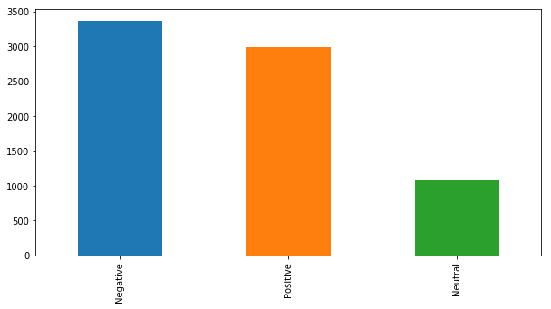

```python
plt.figure().set_size_inches(10, 5)

CountSentiment = pd.value_counts(all_articles_df['Sentiment_Label'].values, sort=True)
print (CountSentiment)

#CountStatus.plot.barh()
CountSentiment.plot.bar()
plt.show()
```

### Looking at articles scored as having positive sentiment

```python
positive = all_articles_df[all_articles_df.Sentiment_Label=="Positive"]
```

```python
positive.count()
```

```
article            2996
Sentiment_Score    2996
Sentiment_Label    2996
dtype: int64
```

```python
positive.head(10)
```

|  | article | Sentiment_Score | Sentiment_Label |
| --- | --- | --- | --- |
| 1 | My View: 2011 worker's comp changes beginning to benefit Illinois My View: 2011 workers comp changes beginning to benefit Illinois Friday Feb 9, 2... | 0.036443 | Positive |
| 3 | 51st Annual Elmhurst College Jazz Festival Begins Feb. 22 - Chicago Tribune The Elmhurst College Jazz Festival enters its 51st year with an allsta... | 0.037209 | Positive |
| 10 | Group aims to bridge gap between NU students, Chicago musicians Send Email Cancel A new group on campus is looking to give a platform to local art... | 0.043118 | Positive |
| 13 | Illinois lawmakers inch closer to new hospital tax despite worries Illinois lawmakers inch closer to new hospital tax despite worries By Benjamin ... | 0.015837 | Positive |
| 14 | What You Should Know About Sales Jobs In Chicago By Jeffrey Lee Thousands of people depend on business for their lively hood. Although there are d... | 0.057823 | Positive |
| 15 | The Art Institute of Chicago Share Visit the worlds best museum, the Art Institute of Chicago. Cover nearly one million square feet of space at th... | 0.039514 | Positive |
| 16 | Chicago Yacht Club Race to Mackinac update With a supporting team of many Old Goats, multihull and monohull racers and cruisers, the Mac Committee... | 0.023256 | Positive |
| 17 | Church becomes 1st in southern Illinois with solar panels Its the first church in southern Illinois to have a solar energy system installed. We lo... | 0.012821 | Positive |
| 19 | North Central Illinois development group touts region North Central Illinois development group touts region Jan. 24, 2018 Photo contributed Captio... | 0.035519 | Positive |
| 22 | Can middle-class candidate defeat millionaires in Illinois? Can middleclass candidate defeat millionaires in Illinois WXOW News 19 La Crosse, WI ... | 0.005780 | Positive |

```python
# going to check for top organizations in the positive articles
import nltk as nltk
import nltk.corpus
from nltk.text import Text
import pandas as pd
import re
import sys

#turn positive text into string
positive_text= str(positive)
```

```python
positive_text[:1000]
```

```
"                                                                                                                                                    article  \\\n1     My View: 2011 worker's comp changes beginning to benefit Illinois My View: 2011 workers comp changes beginning to benefit Illinois F…
```

```python
pos_result = positive.sort_values(by='Sentiment_Score', ascending=False)
```

```python
pos_result.head(50)
```

|  | article | Sentiment_Score | Sentiment_Label |
| --- | --- | --- | --- |
| 496 | nbc, cheer, cheering, chicago pd via giphy.com nbc, cheer, cheering, chicago pd | 0.166667 | Positive |
| 2056 | nbc, cheer, cheering, chicago pd via giphy.com nbc, cheer, cheering, chicago pd | 0.166667 | Positive |
| 4569 | Instead of property tax relief measure, Illinois lawmakers file tax reform sidestep Instead of property tax relief measure, Illinois lawmakers fil... | 0.153846 | Positive |
| 5209 | nbc, cheer, cheering, chicago pd GIF via giphy.com nbc, cheer, cheering, chicago pd | 0.153846 | Positive |
| 90 | nbc, cheer, cheering, chicago pd GIF via giphy.com nbc, cheer, cheering, chicago pd | 0.153846 | Positive |
| 3326 | Not sure what happened \| EveryBlock Chicago LOL Thanks The kids are doing great | 0.142857 | Positive |
| 3269 | Awesome Day / Song: My God Is Awesome - Fellowship Church Chicago Hi This is a wonderful day. I started my new project to pray with a staff at hom... | 0.131868 | Positive |
| 5934 | Classic Chicago neighborhood Love the Willows perfect location for great food and easy access to lots of shops and entertainment Great neighborho... | 0.128205 | Positive |
| 5436 | Good morning Chicago!! Vegas was great, Good morning Chicago Vegas was great, but Im so ready to be home travel chicago vegas vacay fun enjoy live... | 0.117647 | Positive |
| 5197 | Know anything abt suburbs of chicago? moving from westchester. Know anything abt suburbs of chicago moving from westchester. | 0.111111 | Positive |
| 2723 | Chicago skyline, really pretty in person – Chicago Picture Chicago skyline, really pretty in personSource by taymichele6694 link: Chicago skyline,... | 0.107143 | Positive |
| 1632 | How housing could help Chicago bag Amazon's HQ2 - Crain's Chicago Business By Dennis Rodkin How housing could help Chicago bag Amazons HQ2 The ups... | 0.107143 | Positive |
| 5984 | chicago chic chicago chic by yugenstateofmind featuring levi jeans White tee 35 teeparty.jpHooded top pepwear.comLevis levi jeans matchesfashion.... | 0.102564 | Positive |
| 5463 | Wilson Sporting Goods Office by Gensler, Chicago – Illinois Color, light and texture all work together to evoke a strong sense of energy, pride an... | 0.102041 | Positive |
| 6259 | Southern Illinois Soybean Wheat Meeting Having some really fun discussions with AgTalkers at this meeting todayThis group has great ideas. | 0.100000 | Positive |
| 3737 | Winebid no longer allowing pickup in Illinois Im in Illinois... Even with the buyers premium and shipping, theres quite a bit of wine on there tha... | 0.100000 | Positive |
| 3667 | Chicago Cop shot multiple times and died I will be there in April, luckily we will be in the suburbs so I wont venture into the city and get shot.... | 0.100000 | Positive |
| 5487 | In wake of Illinois bail bond reform, advocates here push national legislation Buoyed by last years passage of Illinois bail reform and early resu... | 0.098039 | Positive |
| 645 | Salem iuka even Carlyle asap - m4w (Illinois) favorite this post Salem iuka even Carlyle asap m4w Illinois age: 41 Looking 314for a mutual bene... | 0.095238 | Positive |
| 5847 | Chicago is a beautiful city. #lake #lake Chicago is a beautiful city. lake lakemichigan chicagolake chicago chicagodowntown waters ice snow samsun... | 0.093750 | Positive |
| 5444 | nbc, sure, chicago fire, why not, jesse spencer, matthew casey via giphy.com nbc, sure, chicago fire, why not, jesse spencer, matthew casey | 0.090909 | Positive |
| 1070 | River Cruise - Chicago What is the most recommended river cruise | 0.090909 | Positive |
| 4911 | Chicago To : Moving and Housing advice Hello Folks,We currently live in the Chicago suburbs. This summer we are planning on moving to Boston due t... | 0.088542 | Positive |
| 5927 | Southern Illinois University Edwardsville settles free speech lawsuit Southern Illinois University Edwardsville has settled a lawsuit alleging the... | 0.088235 | Positive |
| 2451 | Attorney / - Illinois-Chicago Illinois Chicago Submit Resume Chicago office of our client seeks real estate partner with substantial experience i... | 0.085714 | Positive |
| 5884 | Illinois: Red light camera to be installed in the Chicago Loop Illinois: Red light camera to be installed in the Chicago Loop February 19, 2018 A ... | 0.085106 | Positive |
| 3747 | 1910 Prairie – Chicago, IL – $525,000 Acres 0.21 Stunning woodwork and master craftmanship abound in this classic historical home 2nd owners of th... | 0.084967 | Positive |
| 5501 | ComEd's Chicago South Side microgrid hits a nerve Kolata said hes hopeful the Bronzeville project will help ComEd and the state build on key polic... | 0.084507 | Positive |
| 5461 | Illinois Governors race ad I wish more ads like that were ran. | 0.083333 | Positive |
| 771 | My View: 2011 worker’s comp changes beginning to benefit Illinois http:ift.tt2G1Ysz7 | 0.083333 | Positive |
| 414 | State rep wants to mirror federal K-12 savings benefits in Illinois State rep wants to mirror federal K12 savings benefits in Illinois | 0.083333 | Positive |
| 4053 | Hollywood's 'go-to medium' brings psychic abilities to Hammond casino - Chicago Tribune Hollywoods goto medium brings psychic abilities to Hammond... | 0.083333 | Positive |
| 3243 | Call an Amazon truce, top economists tell cities vying for HQ2 - Government News - Crain's Chicago Business February 01, 2018 Call an Amazon truce... | 0.081967 | Positive |
| 5232 | Amazing School \| EveryBlock Chicago ExcellentSt Bruno Catholic School has exceeded my expectations on my childs education The teachers are amazing... | 0.081633 | Positive |
| 757 | Historic Neighborhoods - Chicago Hi, I was curious what are some neighborhoods of Chicago where you can see an abundance of historic buildings and... | 0.080000 | Positive |
| 827 | Feb 11: Illinois 8th Senate District Candidates Forum I hope you have a successful forum and that folks arent kept at home by the snow. | 0.080000 | Positive |
| 4914 | Mr. Illini maps Illinois: 2018 edition Also, well revisit a map that I shared elsewhere previously, the 2010 IL Senate Dem Primary map, including ... | 0.079710 | Positive |
| 1460 | Illinois State Rep. Breen files legislation to eliminate red light cameras in DuPage County February 8, 2018 State Rep. Peter Breen, RLombard, is ... | 0.079646 | Positive |
| 6756 | University of Chicago students, faculty protest potential campus visit from 'white supremacist' Steve ... The University of Chicago is deeply comm... | 0.079365 | Positive |
| 5179 | North Shore Chicago Burbs PPI and Service Im about to get a 2011 Cayenne S. Looking for recommendations for independent service near the northshor... | 0.078431 | Positive |
| 4812 | Chicago NW Suburbs HP Tuner recommendation? Chicago NW Suburbs HP Tuner recommendation Hey Everyone:Ive been looking for a local HP tuner in the N... | 0.078431 | Positive |
| 574 | Chicago NW Suburbs HP Tuner recommendation? Chicago NW Suburbs HP Tuner recommendation Hey Everyone:Ive been looking for a local HP tuner in the N... | 0.078431 | Positive |
| 7097 | Singapore’s Olam to open U.S. cocoa powder plant in Chicago area | 0.076923 | Positive |
| 5951 | is chicago a city that good to travel on budget? i is chicago a city that good to travel on budgeti mean its cheaper than west coast.i wish to see... | 0.076923 | Positive |
| 5640 | What are the odds we will get a foot of snow in Chicago? What are the odds we will get a foot of snow in Chicago | 0.076923 | Positive |
| 2047 | Illinois governor \| Letters \| pantagraph.com Save I viewed the You Tube video of the FBI taped conversation between J.D. Pritzker and Rod Blagojev... | 0.076923 | Positive |
| 634 | Raoul, Biss, Garcia land significant endorsements - Blogs On Politics - Crain's Chicago Business Greg Hinz on Politics Raoul, Biss, Garcia land si... | 0.075472 | Positive |
| 803 | Happy to be here from Illinois Hi all, Im Stephen from Central Illinois. Im a life long firearms enthusiast, collector, reloader,and competitive s... | 0.074627 | Positive |
| 2766 | Robert Rauschenberg's Rare Duchamp Readymade Goes to Art Institute of Chicago ARTnews Those visiting the Art Institute of Chicago this morning are... | 0.073529 | Positive |
| 5186 | Chicago approves $700M mixed-use project, includes city’s future 6th-tallest tower Developers have agreed to contribute to local affordable housin... | 0.071429 | Positive |

```python
positive_text= str(pos_result[:300])
```

```python
import os
from graphviz import Source

java_path = "C:\ProgramData\Oracle\Java\javapath\java.exe"
os.environ['JAVAHOME'] = java_path

# Change the path according to your system
stanford_classifier = 'C:\Program Files\stanford-ner-2017-06-09\classifiers\english.all.3class.distsim.crf.ser.gz'
stanford_ner_path = 'C:\Program Files\stanford-ner-2017-06-09\stanford-ner.jar'

stanford_parser_path = 'C:\Program Files\stanford-parser-full-2017-06-09\stanford-parser.jar'
stanford_parser_models_path = 'C:\Program Files\stanford-parser-full-2017-06-09\stanford-parser-3.8.0-models.jar'

from nltk.parse.stanford import StanfordDependencyParser
from nltk.tag.stanford import StanfordNERTagger

# Creating Tagger Object
st = StanfordNERTagger(stanford_classifier, stanford_ner_path, encoding='utf-8')
sdp = StanfordDependencyParser(path_to_jar=stanford_parser_path, path_to_models_jar=stanford_parser_models_path)
```

```python
#tokenizing and tagging text
tokenized_positive_text = nltk.word_tokenize(positive_text)
classified_positive_text = st.tag(tokenized_positive_text)

classified_p_text_df = pd.DataFrame(classified_positive_text)

classified_p_text_df.drop_duplicates(keep='first', inplace=True)
classified_p_text_df.reset_index(drop=True, inplace=True)
classified_p_text_df.columns = ["Entities", "Labels"]
```

```python
#counts by labels
classified_p_text_df.groupby("Labels").count()
```

| Labels | Entities |
| --- | --- |
| LOCATION | 17 |
| O | 703 |
| ORGANIZATION | 71 |
| PERSON | 22 |

```python
#list of organization
entities_df = classified_p_text_df.loc[classified_p_text_df["Labels"].isin(['LOCATION','ORGANIZATION','PERSON'])]
entities_df.reset_index(drop=True, inplace=True)
entities_df.head(20)
```

|  | Entities | Labels |
| --- | --- | --- |
| 0 | Illinois | LOCATION |
| 1 | Chicago | LOCATION |
| 2 | Vegas | PERSON |
| 3 | Vegas | LOCATION |
| 4 | Chicago | ORGANIZATION |
| 5 | Picture | ORGANIZATION |
| 6 | bag | ORGANIZATION |
| 7 | Amazon | ORGANIZATION |
| 8 | Crain | PERSON |
| 9 | Dennis | PERSON |
| 10 | Rodkin | PERSON |
| 11 | Wilson | ORGANIZATION |
| 12 | Sporting | ORGANIZATION |
| 13 | Goods | ORGANIZATION |
| 14 | Office | ORGANIZATION |
| 15 | Gensler | PERSON |
| 16 | Southern | ORGANIZATION |
| 17 | Illinois | ORGANIZATION |
| 18 | Soybean | ORGANIZATION |
| 19 | Wheat | ORGANIZATION |

```python
#per class notes, the Stanford NER tagger does have capability to support multi-word NER
tokenized_text = nltk.word_tokenize(positive_text)
classified_text = st.tag(tokenized_text)

netagged_words = classified_text

entities = []
labels = []

from itertools import groupby
for tag, chunk in groupby(classified_text, lambda x:x[1]):
    if tag != "O":
        #print("%-12s"%tag, " ".join(w for w, t in chunk))
        entities.append(' '.join(w for w, t in chunk))
        labels.append(tag)


entities_all = list(zip(entities, labels))
entities_unique = list(set(zip(entities, labels))) #unique entities
```

```python
entities_df = pd.DataFrame(entities_unique)
entities_df.columns = ["Entities", "Labels"]
entities_df.groupby('Labels').count()
```

| Labels | Entities |
| --- | --- |
| LOCATION | 16 |
| ORGANIZATION | 31 |
| PERSON | 15 |

```python
entities_df = pd.DataFrame(entities_all)
entities_df.columns = ["Entities", "Labels"]
persons_df = entities_df.loc[entities_df["Labels"].isin(['LOCATION','ORGANIZATION','PERSON'])]
counts_df = persons_df.groupby('Entities').count()
counts_df.rename(columns={"Labels": "Mentions"}, inplace=True)
counts_df.sort_values(by=['Mentions'], ascending=False).head(50)
```

| Entities | Mentions |
| --- | --- |
| Chicago | 24 |
| Illinois | 20 |
| Elmhurst College Jazz Festival Begins | 2 |
| Elmhurst College Jazz Festival | 2 |
| ComEd | 2 |
| Hyperloop Transportation Technologies | 2 |
| Salem | 2 |
| Southern Illinois University Edwardsville | 2 |
| Art Institute | 2 |
| West Chicago Street | 2 |
| Carlyle | 2 |
| Blockchain Illinois | 2 |
| MENU Split Illinois | 1 |
| Illinois Senate | 1 |
| Illinois Senate Committee | 1 |
| Wilson Sporting Goods Office | 1 |
| Illinois-Chicago Illinois Chicago Submit Resume Chicago | 1 |
| Illinois-Edwardsville | 1 |
| Kolata | 1 |
| Lincoln | 1 |
| Lisa Madigan | 1 |
| Tanya Manus | 1 |
| Split Illinois | 1 |
| MERRILLVILLE | 1 |
| Matt Finn | 1 |
| NBC Chicago | 1 |
| Obama Center | 1 |
| West Chicago High School | 1 |
| Reclaim Chicago Endorse | 1 |
| Vegas | 1 |
| Senate | 1 |
| Southern Illinois Soybean Wheat Meeting Having | 1 |
| RDA | 1 |
| Emerging Business Partners | 1 |
| Hatchery Chicago Breaking News Ingredion for Emerging Business Partners | 1 |
| Chicago Tribune Random News Chicago TribuneLocal | 1 |
| Art Institute of Chicago Share Visit | 1 |
| Boston | 1 |
| Bronzeville | 1 |
| CTU | 1 |
| Cassandra Smith | 1 |
| Chicago Loop Illinois | 1 |
| Chicago Picture Chicago | 1 |
| Chicago Roof Top | 1 |
| Chicago South Side | 1 |
| Chicago Teachers Union Charter | 1 |
| Chicago Tribune News | 1 |
| Chicago Vegas | 1 |
| Hammond | 1 |
| Chicago bag Amazon | 1 |

```python
from wordcloud import WordCloud
```

```python
entities= str(entities_df['Entities'])
```

```python
wordcloud = WordCloud().generate(entities)
```

```
(-0.5, 399.5, 199.5, -0.5)
```

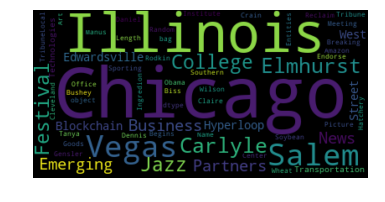

```python
plt.imshow(wordcloud, interpolation='bilinear')
plt.axis("off")
```

#### Topic modeling among the postiive sentiment articles

```python
pos_list = positive['article'].tolist()
pos_list[:1]
```

```
["My View: 2011 worker's comp changes beginning to benefit Illinois My View: 2011 workers comp changes beginning to benefit Illinois Friday Feb 9, 2018 at 3:49 PM Feb 9, 2018 at 3:49 PM By John P. Scanlon In 2011, at the urging of the states leading business organizations, bipartisan majorities of I…
```

```python
stop = set(stopwords.words('english'))
exclude = set(string.punctuation)
lemma = WordNetLemmatizer()
def clean(doc):
    stop_free = " ".join([i for i in doc.lower().split() if i not in stop])
    punc_free = ''.join(ch for ch in stop_free if ch not in exclude)
    normalized = " ".join(lemma.lemmatize(word) for word in punc_free.split())
    return normalized

doc_clean = [clean(doc).split() for doc in pos_list]
```

```python
# Creating the term dictionary of our courpus, where every unique term is assigned an index.
dictionary = corpora.Dictionary(doc_clean)

# Converting list of documents (corpus) into Document Term Matrix using dictionary prepared above.
doc_term_matrix = [dictionary.doc2bow(doc) for doc in doc_clean]
```

```python
# Creating the object for LDA model using gensim library
Lda = gensim.models.ldamodel.LdaModel
```

```python
pos_clean = [clean(doc).split() for doc in pos_list]
```

```python
len(pos_clean)
```

```
2996
```

```python
print(*pos_clean[:1], sep='\n\n')
```

```
['view', '2011', 'worker', 'comp', 'change', 'beginning', 'benefit', 'illinois', 'view', '2011', 'worker', 'comp', 'change', 'beginning', 'benefit', 'illinois', 'friday', 'feb', '9', '2018', '349', 'pm', 'feb', '9', '2018', '349', 'pm', 'john', 'p', 'scanlon', '2011', 'urging', 'state', 'leading', '…
```

```python
# Creating the term dictionary of our courpus, where every unique term is assigned an index.

dictionary = corpora.Dictionary(pos_clean)

# Converting list of documents (corpus) into Document Term Matrix using dictionary prepared above.

%time doc_term_matrix = [dictionary.doc2bow(doc) for doc in pos_clean]
```

```
Wall time: 1.68 s
```

#### 3 topic model

```python
# Creating the object for LDA model using gensim library
Lda = gensim.models.ldamodel.LdaModel
numtopics = 3

# Running and Training LDA model on the document term matrix.
%time ldamodel = Lda(doc_term_matrix, num_topics=numtopics, id2word = dictionary, passes=50)
```

```
Wall time: 15min 50s
```

```python
print(*ldamodel.print_topics(num_topics=numtopics, num_words=3), sep='\n\n')
```

```
(0, '0.014*"illinois" + 0.013*"state" + 0.008*"said"')

(1, '0.024*"chicago" + 0.009*"said" + 0.008*"snow"')

(2, '0.012*"democratic" + 0.012*"illinois" + 0.012*"pritzker"')
```

```python
print(*ldamodel.print_topics(num_topics=numtopics, num_words=5), sep='\n\n')
```

```
(0, '0.014*"illinois" + 0.013*"state" + 0.008*"said" + 0.007*"chicago" + 0.006*"would"')

(1, '0.024*"chicago" + 0.009*"said" + 0.008*"snow" + 0.008*"city" + 0.005*"school"')

(2, '0.012*"democratic" + 0.012*"illinois" + 0.012*"pritzker" + 0.011*"candidate" + 0.011*"bi"')
```

```python
print(*ldamodel.print_topics(num_topics=numtopics, num_words=7), sep='\n\n')
```

```
(0, '0.014*"illinois" + 0.013*"state" + 0.008*"said" + 0.007*"chicago" + 0.006*"would" + 0.006*"tax" + 0.006*"year"')

(1, '0.024*"chicago" + 0.009*"said" + 0.008*"snow" + 0.008*"city" + 0.005*"school" + 0.005*"county" + 0.004*"area"')

(2, '0.012*"democratic" + 0.012*"illinois" + 0.012*"pritzker" + 0.011*"candidate" + 0.011*"bi" + 0.010*"campaign" + 0.008*"said"')
```

```python
print(*ldamodel.print_topics(num_topics=numtopics, num_words=10), sep='\n\n')
```

```
(0, '0.014*"illinois" + 0.013*"state" + 0.008*"said" + 0.007*"chicago" + 0.006*"would" + 0.006*"tax" + 0.006*"year" + 0.006*"school" + 0.004*"public" + 0.004*"new"')

(1, '0.024*"chicago" + 0.009*"said" + 0.008*"snow" + 0.008*"city" + 0.005*"school" + 0.005*"county" + 0.004*"area" + 0.004*"friday" + 0.004*"illinois" + 0.004*"street"')

(2, '0.012*"democratic" + 0.012*"illinois" + 0.012*"pritzker" + 0.011*"candidate" + 0.011*"bi" + 0.010*"campaign" + 0.008*"said" + 0.007*"primary" + 0.007*"trump" + 0.007*"democrat"')
```

#### 5 topic model

```python
# Creating the object for LDA model using gensim library
Lda = gensim.models.ldamodel.LdaModel
numtopics = 5

# Running and Training LDA model on the document term matrix.
%time ldamodel = Lda(doc_term_matrix, num_topics=numtopics, id2word = dictionary, passes=50)
```

```
Wall time: 16min 53s
```

```python
print(*ldamodel.print_topics(num_topics=numtopics, num_words=3), sep='\n\n')
```

```
(0, '0.019*"chicago" + 0.011*"school" + 0.010*"said"')

(1, '0.016*"pritzker" + 0.015*"bi" + 0.011*"illinois"')

(2, '0.012*"chicago" + 0.011*"snow" + 0.009*"illinois"')

(3, '0.023*"chicago" + 0.010*"city" + 0.007*"said"')

(4, '0.017*"illinois" + 0.016*"state" + 0.008*"said"')
```

```python
print(*ldamodel.print_topics(num_topics=numtopics, num_words=5), sep='\n\n')
```

```
(0, '0.019*"chicago" + 0.011*"school" + 0.010*"said" + 0.008*"student" + 0.006*"illinois"')

(1, '0.016*"pritzker" + 0.015*"bi" + 0.011*"illinois" + 0.010*"campaign" + 0.010*"said"')

(2, '0.012*"chicago" + 0.011*"snow" + 0.009*"illinois" + 0.007*"said" + 0.006*"democratic"')

(3, '0.023*"chicago" + 0.010*"city" + 0.007*"said" + 0.005*"police" + 0.004*"park"')

(4, '0.017*"illinois" + 0.016*"state" + 0.008*"said" + 0.008*"tax" + 0.007*"would"')
```

```python
print(*ldamodel.print_topics(num_topics=numtopics, num_words=7), sep='\n\n')
```

```
(0, '0.019*"chicago" + 0.011*"school" + 0.010*"said" + 0.008*"student" + 0.006*"illinois" + 0.006*"hospital" + 0.006*"court"')

(1, '0.016*"pritzker" + 0.015*"bi" + 0.011*"illinois" + 0.010*"campaign" + 0.010*"said" + 0.009*"candidate" + 0.008*"chicago"')

(2, '0.012*"chicago" + 0.011*"snow" + 0.009*"illinois" + 0.007*"said" + 0.006*"democratic" + 0.006*"primary" + 0.006*"district"')

(3, '0.023*"chicago" + 0.010*"city" + 0.007*"said" + 0.005*"police" + 0.004*"park" + 0.004*"street" + 0.004*"new"')

(4, '0.017*"illinois" + 0.016*"state" + 0.008*"said" + 0.008*"tax" + 0.007*"would" + 0.006*"year" + 0.006*"school"')
```

```python
print(*ldamodel.print_topics(num_topics=numtopics, num_words=10), sep='\n\n')
```

```
(0, '0.019*"chicago" + 0.011*"school" + 0.010*"said" + 0.008*"student" + 0.006*"illinois" + 0.006*"hospital" + 0.006*"court" + 0.006*"law" + 0.005*"city" + 0.005*"park"')

(1, '0.016*"pritzker" + 0.015*"bi" + 0.011*"illinois" + 0.010*"campaign" + 0.010*"said" + 0.009*"candidate" + 0.008*"chicago" + 0.008*"democratic" + 0.008*"governor" + 0.007*"rauner"')

(2, '0.012*"chicago" + 0.011*"snow" + 0.009*"illinois" + 0.007*"said" + 0.006*"democratic" + 0.006*"primary" + 0.006*"district" + 0.005*"county" + 0.005*"democrat" + 0.005*"u"')

(3, '0.023*"chicago" + 0.010*"city" + 0.007*"said" + 0.005*"police" + 0.004*"park" + 0.004*"street" + 0.004*"new" + 0.004*"year" + 0.003*"building" + 0.003*"one"')

(4, '0.017*"illinois" + 0.016*"state" + 0.008*"said" + 0.008*"tax" + 0.007*"would" + 0.006*"year" + 0.006*"school" + 0.004*"public" + 0.004*"new" + 0.004*"people"')
```

### Looking at the articles scored as having negative sentiment

```python
negative = all_articles_df[all_articles_df.Sentiment_Label=="Negative"]
```

```python
negative.head(20)
```

|  | article | Sentiment_Score | Sentiment_Label |
| --- | --- | --- | --- |
| 0 | Man dies hours after being shot leaving Southwest Side party - Chicago Tribune TribuneMan dies hours after being shot leaving Southwest Side par... | -0.014706 | Negative |
| 2 | Illinois governor candidate stands by ad blasted as racist CHICAGO AP A Republican lawmaker trying to unseat Illinois Gov. Bruce Rauner is standi... | -0.068182 | Negative |
| 4 | 6 shot within 3 hours to start President's Day weekend in Chicago \| 1 killed, 12 wounded in shootings across Chicago since Friday evening SunTimes... | -0.017391 | Negative |
| 5 | Toys R Us closing seven Chicago area stores Toys R Us closing seven Chicago area stores Jan 24, 2018 WLSAM Staff By Jennifer Keiper, WLSAM News C... | -0.003597 | Negative |
| 7 | Holocaust denier running for Congress has no opponents in Illinois Republican primary Holocaust denier running for Congress has no opponents in Il... | -0.014409 | Negative |
| 8 | Black NHL player Devante Smith-Pelly taunted by Chicago fans Black NHL player Devante SmithPelly taunted by Chicago fans WGEM.com: Quincy News, W... | -0.035599 | Negative |
| 11 | Duerson Act would ban pre-teen tackle football in Illinois Duerson Act would ban preteen tackle football in Illinois By Jimmy Golen And Caryn Rous... | -0.014056 | Negative |
| 12 | Oak Park Police Investigate Alleged Abduction « CBS Chicago Sponsored By Oak Park Police Investigate Alleged Abduction Oak Park Police are investi... | -0.016949 | Negative |
| 18 | Owens-Illinois Inc (OI) Files 10-K for the Fiscal Year Ended on December 31, 2017 Peter Lynch Chart of OI The reported diluted earnings per share ... | -0.018779 | Negative |
| 20 | The Latest: Slain Chicago officer remembered as 'model cop' The Latest: Slain Chicago officer remembered as model cop wistv.com Columbia, South ... | -0.001845 | Negative |
| 26 | Illinois Veterinarian Has More To Say About This 🐶 Dog Flu😷 Dog Insurance News Illinois Veterinarian Has More To Say About This Dog Flu Dog flu h... | -0.042969 | Negative |
| 28 | Chicago police commander killed, 5 others wounded in city shootings - Chicago Tribune A Chicago police commander has been killed in the Loop and f... | -0.023973 | Negative |
| 34 | Illinois Gov. Bruce Rauner to deliver State of the State Email Want to read through the speech Click here SPRINGFIELD, Ill. AP Illinois Gov. Bruc... | -0.020270 | Negative |
| 38 | Illinois Smoking Ban Has Not Damaged Casino Revenue, Study Claims News Live Casinos Illinois Smoking Ban Has Not Damaged Casino Revenue, Study C... | -0.011050 | Negative |
| 41 | Heavy Snow, White-Out Conditions Cause 11-Car Crash in Indiana - NBC Chicago The latest local news, weather and investigative stories impacting yo... | -0.015810 | Negative |
| 42 | Biggest snow in over a year bearing down on large swath of the Chicago area beginning Thursday night; Friday rush hours in jeopardy; wide swath of... | -0.018692 | Negative |
| 46 | Another Chicago-area school closes due to flu A school in North Riverside will be closed for the rest of the week because of a flu outbreak, makin... | -0.013115 | Negative |
| 47 | Southwest Air's Chicago De-Icing Stumble Was Third in Two Months Southwest Airlines Co.s cancellation of 250 flights at Midway Airport Feb. 11 was... | -0.007519 | Negative |
| 50 | CTA riders facing significant Monday morning delays \| Chicago Sun-Times Nearly every CTA line was operating with residual delays Monday morning, c... | -0.013514 | Negative |
| 52 | Oboi Reed Blasts the City’s Failure to Address Its Biased Bike Ticketing Problem – Streetsblog Chicago Share Last week the Chicago Tribunes Mary W... | -0.008403 | Negative |

```python
neg_result= negative.sort_values(by=['Sentiment_Score'])
```

```python
neg_result.head(20)
```

|  | article | Sentiment_Score | Sentiment_Label |
| --- | --- | --- | --- |
| 856 | Chicago public schools close tomorrow. Chicago public schools close tomorrow. | -0.200000 | Negative |
| 7289 | Illinois lawmakers inch closer to new hospital tax despite worries | -0.181818 | Negative |
| 125 | Illegals, Chicago and ‘loathsome little demagogues’ Illegals, Chicago and loathsome little demagogues Republican Chicago Alderman Nicholas Sposato... | -0.176471 | Negative |
| 3287 | Ex-staffer: Top Illinois Democrats slow to probe sex harassment claim http:ift.tt2GaeUx4 | -0.166667 | Negative |
| 3315 | Illegals, Chicago and 'loathsome little demagogues' \| On Air Republican Chicago Alderman Nicholas Sposato responds to Tuckers controversial interv... | -0.161290 | Negative |
| 4444 | Shootings in Chicago continue These last two posts kinda blow the opposition away. | -0.153846 | Negative |
| 4394 | Government watchdog: States like Illinois must be more accountable for infrastructure maintenance | -0.153846 | Negative |
| 4297 | Shootings in Chicago continue These last two posts kinda blow the opposition away. | -0.153846 | Negative |
| 7263 | Calls for investigations, new leadership, rock Democratic Party of Illinois following harassment scandal | -0.142857 | Negative |
| 5597 | Chicago rocks! If you dig rock and roll history , then enjoy this little lesson. | -0.133333 | Negative |
| 5226 | Illegals, Chicago and ‘loathsome little demagogues’ Republican Chicago Alderman Nicholas Sposato responds to Tuckers controversial interview on il... | -0.133333 | Negative |
| 3895 | Also seen from the Chicago Autoshow: 50th anniversary badging God Damn hyper blues are fucking sick with the black rims and black badging. | -0.130435 | Negative |
| 7180 | Chicago police teaming up with feds once more to fight shocking rise in violent carjackings Chicago police teaming up with feds once more to fight... | -0.125654 | Negative |
| 3525 | Lawyers argue for firing squad for Ohio death row inmate after unsuccessful lethal injection - Chicago Tribune Share A firing squad wouldnt cause ... | -0.120482 | Negative |
| 239 | Slain Chicago cop advocated for stiffer sentences; suspect in his shooting is a 4-time felon Home International News Slain Chicago cop advocated... | -0.120000 | Negative |
| 1816 | Illinois cattle disease study in need of farm cooperators in Southern Illinois Illinois cattle producers have been seeing more cases of a serious ... | -0.117647 | Negative |
| 6936 | Man convicted in deadly 2012 Indianapolis house explosion dies in prison – Chicago Tribune Man convicted in deadly 2012 Indianapolis house explo... | -0.116279 | Negative |
| 292 | Fellow detainees applauded suspected Chicago cop killer: report Fellow detainees applauded suspected Chicago cop killer: report Fellow detainees... | -0.115385 | Negative |
| 669 | Brian Mackey talks Illinois budget, sexual harassment claims against Madigan \| WGN Radio - 720 AM Brian Mackey talks Illinois budget, sexual haras... | -0.114754 | Negative |
| 3478 | Northwestern professor takes leave of absence amid harassment allegations - Chicago Sun-Times Northwestern professor takes leave of absence amid h... | -0.114754 | Negative |

```python
#turn NEGATIVE text into string
negative_text= str(neg_result[:200])
```

```python
negative_text
```

```
"                                                                                                                                                    article  \\\n856                                                                           Chicago public schools close tomorrow. Chicago public school…
```

```python
#tokenizing and tagging text
tokenized_text = nltk.word_tokenize(negative_text)
classified_text = st.tag(tokenized_text)

classified_text_df = pd.DataFrame(classified_text)

classified_text_df.drop_duplicates(keep='first', inplace=True)
classified_text_df.reset_index(drop=True, inplace=True)
classified_text_df.columns = ["Entities", "Labels"]
```

```python
#counts by labels
classified_text_df.groupby("Labels").count()
```

| Labels | Entities |
| --- | --- |
| LOCATION | 19 |
| O | 621 |
| ORGANIZATION | 42 |
| PERSON | 20 |

```python
#list of organization
entities_df = classified_text_df.loc[classified_text_df["Labels"].isin(['LOCATION','ORGANIZATION','PERSON'])]
entities_df.reset_index(drop=True, inplace=True)
entities_df.head(20)
```

|  | Entities | Labels |
| --- | --- | --- |
| 0 | Chicago | LOCATION |
| 1 | Illinois | LOCATION |
| 2 | Chicago | PERSON |
| 3 | Alderman | PERSON |
| 4 | Nicholas | PERSON |
| 5 | Sposato | PERSON |
| 6 | Tuckers | ORGANIZATION |
| 7 | Democratic | ORGANIZATION |
| 8 | Party | ORGANIZATION |
| 9 | of | ORGANIZATION |
| 10 | Illinois | ORGANIZATION |
| 11 | Ohio | LOCATION |
| 12 | Chicago | ORGANIZATION |
| 13 | Tribune | ORGANIZATION |
| 14 | Indianapolis | LOCATION |
| 15 | Brian | PERSON |
| 16 | Mackey | PERSON |
| 17 | Madigan | PERSON |
| 18 | WGN | ORGANIZATION |
| 19 | Radio | ORGANIZATION |

```python
#per class notes, the Stanford NER tagger does have capability to support multi-word NER
tokenized_text = nltk.word_tokenize(negative_text)
classified_text = st.tag(tokenized_text)

netagged_words = classified_text

entities = []
labels = []

from itertools import groupby
for tag, chunk in groupby(classified_text, lambda x:x[1]):
    if tag != "O":
        #print("%-12s"%tag, " ".join(w for w, t in chunk))
        entities.append(' '.join(w for w, t in chunk))
        labels.append(tag)


entities_all = list(zip(entities, labels))
entities_unique = list(set(zip(entities, labels))) #unique entities
```

```python
entities_df = pd.DataFrame(entities_unique)
entities_df.columns = ["Entities", "Labels"]
entities_df.groupby('Labels').count()
```

| Labels | Entities |
| --- | --- |
| LOCATION | 13 |
| ORGANIZATION | 21 |
| PERSON | 10 |

```python
entities_df = pd.DataFrame(entities_all)
entities_df.columns = ["Entities", "Labels"]
persons_df = entities_df.loc[entities_df["Labels"].isin(['LOCATION','ORGANIZATION','PERSON'])]
counts_df = persons_df.groupby('Entities').count()
counts_df.rename(columns={"Labels": "Mentions"}, inplace=True)
counts_df.sort_values(by=['Mentions'], ascending=False).head(200)
```

| Entities | Mentions |
| --- | --- |
| Chicago | 48 |
| Illinois | 22 |
| Illinois Corrections Department | 4 |
| Chicago Tribune | 4 |
| Chicago Alderman Nicholas Sposato | 3 |
| Brian Mackey | 2 |
| CHICAGO | 2 |
| Indianapolis | 2 |
| Tuckers | 2 |
| Illinois Arlington Heights Cook County | 2 |
| Home International News | 2 |
| Steve Bannon | 2 |
| SOPHIA TAREEN | 1 |
| NPR | 1 |
| Ohio | 1 |
| PBS | 1 |
| Transgender Inmates Sue Illinois Corrections Department | 1 |
| Thomas Lindstrom | 1 |
| Marquette Park | 1 |
| Transgender Inmates Sue Illinois Corrections Department Illinois News | 1 |
| Tyler Durden | 1 |
| Ukrainian Village | 1 |
| University of Chicago\| Latest News Raw | 1 |
| WGN Radio | 1 |
| Washington Post | 1 |
| Mount Vernon Illinois Jefferson County | 1 |
| Illinois Illinois | 1 |
| Madigan | 1 |
| Latoya Frost | 1 |
| La Salle | 1 |
| Bruce Rauner | 1 |
| Greece | 1 |
| Democratic Party of Illinois | 1 |
| Democratic Party | 1 |
| Cicero | 1 |
| Chicago Tribune Storm | 1 |
| Chicago Sun-Times Northwestern | 1 |
| Chicago Loop | 1 |
| Chicago Daily Herald Elgin | 1 |
| CTA | 1 |
| CHICAGO AP A Republican | 1 |
| CHICAGO AP | 1 |
| West | 1 |

```python
#topic modeling on negative sentiment articles
neg_list = neg_result['article'].tolist()
neg_list[:1]
```

```
['Chicago public schools close tomorrow. Chicago public schools close tomorrow.']
```

```python
stop = set(stopwords.words('english'))
exclude = set(string.punctuation)
lemma = WordNetLemmatizer()
def clean(doc):
    stop_free = " ".join([i for i in doc.lower().split() if i not in stop])
    punc_free = ''.join(ch for ch in stop_free if ch not in exclude)
    normalized = " ".join(lemma.lemmatize(word) for word in punc_free.split())
    return normalized

neg_clean = [clean(doc).split() for doc in neg_list]
```

```python
# Creating the term dictionary of our courpus, where every unique term is assigned an index.
dictionary = corpora.Dictionary(neg_clean)

# Converting list of documents (corpus) into Document Term Matrix using dictionary prepared above.
doc_term_matrix = [dictionary.doc2bow(doc) for doc in neg_clean]
```

```python
# Creating the object for LDA model using gensim library
Lda = gensim.models.ldamodel.LdaModel
```

```python
neg_clean = [clean(doc).split() for doc in neg_list]
```

```python
len(neg_clean)
```

```
3367
```

```python
print(*neg_clean[:1], sep='\n\n')
```

```
['chicago', 'public', 'school', 'close', 'tomorrow', 'chicago', 'public', 'school', 'close', 'tomorrow']
```

```python
# Creating the term dictionary of our courpus, where every unique term is assigned an index.

dictionary = corpora.Dictionary(neg_clean)

# Converting list of documents (corpus) into Document Term Matrix using dictionary prepared above.

%time doc_term_matrix = [dictionary.doc2bow(doc) for doc in neg_clean]
```

```
Wall time: 1.21 s
```

#### 3 topic model

```python
# Creating the object for LDA model |using gensim library
Lda = gensim.models.ldamodel.LdaModel
numtopics = 3

# Running and Training LDA model on the document term matrix.
%time ldamodel = Lda(doc_term_matrix, num_topics=numtopics, id2word = dictionary, passes=50)
```

```
Wall time: 19min 44s
```

```python
print(*ldamodel.print_topics(num_topics=numtopics, num_words=3), sep='\n\n')
```

```
(0, '0.016*"school" + 0.013*"chicago" + 0.010*"said"')

(1, '0.016*"illinois" + 0.013*"chicago" + 0.012*"state"')

(2, '0.021*"chicago" + 0.016*"police" + 0.013*"said"')
```

```python
print(*ldamodel.print_topics(num_topics=numtopics, num_words=5), sep='\n\n')
```

```
(0, '0.016*"school" + 0.013*"chicago" + 0.010*"said" + 0.007*"student" + 0.006*"year"')

(1, '0.016*"illinois" + 0.013*"chicago" + 0.012*"state" + 0.010*"snow" + 0.008*"said"')

(2, '0.021*"chicago" + 0.016*"police" + 0.013*"said" + 0.010*"football" + 0.008*"shooting"')
```

```python
print(*ldamodel.print_topics(num_topics=numtopics, num_words=7), sep='\n\n')
```

```
(0, '0.016*"school" + 0.013*"chicago" + 0.010*"said" + 0.007*"student" + 0.006*"year" + 0.005*"new" + 0.005*"state"')

(1, '0.016*"illinois" + 0.013*"chicago" + 0.012*"state" + 0.010*"snow" + 0.008*"said" + 0.005*"inch" + 0.005*"say"')

(2, '0.021*"chicago" + 0.016*"police" + 0.013*"said" + 0.010*"football" + 0.008*"shooting" + 0.007*"man" + 0.007*"shot"')
```

```python
print(*ldamodel.print_topics(num_topics=numtopics, num_words=10 ), sep='\n\n')
```

```
(0, '0.016*"school" + 0.013*"chicago" + 0.010*"said" + 0.007*"student" + 0.006*"year" + 0.005*"new" + 0.005*"state" + 0.005*"say" + 0.004*"pritzker" + 0.004*"illinois"')

(1, '0.016*"illinois" + 0.013*"chicago" + 0.012*"state" + 0.010*"snow" + 0.008*"said" + 0.005*"inch" + 0.005*"say" + 0.005*"weather" + 0.005*"flight" + 0.005*"friday"')

(2, '0.021*"chicago" + 0.016*"police" + 0.013*"said" + 0.010*"football" + 0.008*"shooting" + 0.007*"man" + 0.007*"shot" + 0.007*"officer" + 0.006*"illinois" + 0.006*"news"')
```

### 5 topic modeling

```python
# Creating the object for LDA model using gensim library
Lda = gensim.models.ldamodel.LdaModel
numtopics = 5

# Running and Training LDA model on the document term matrix.
%time ldamodel = Lda(doc_term_matrix, num_topics=numtopics, id2word = dictionary, passes=50)
```

```
Wall time: 16min 34s
```

```python
print(*ldamodel.print_topics(num_topics=numtopics, num_words=3), sep='\n\n')
```

```
(0, '0.022*"football" + 0.016*"said" + 0.012*"tackle"')

(1, '0.012*"said" + 0.011*"chicago" + 0.007*"illinois"')

(2, '0.018*"illinois" + 0.017*"state" + 0.008*"said"')

(3, '0.022*"chicago" + 0.019*"snow" + 0.010*"inch"')

(4, '0.029*"chicago" + 0.020*"police" + 0.016*"school"')
```

```python
print(*ldamodel.print_topics(num_topics=numtopics, num_words=5), sep='\n\n')
```

```
(0, '0.022*"football" + 0.016*"said" + 0.012*"tackle" + 0.012*"illinois" + 0.011*"duerson"')

(1, '0.012*"said" + 0.011*"chicago" + 0.007*"illinois" + 0.006*"year" + 0.006*"city"')

(2, '0.018*"illinois" + 0.017*"state" + 0.008*"said" + 0.006*"tax" + 0.006*"year"')

(3, '0.022*"chicago" + 0.019*"snow" + 0.010*"inch" + 0.009*"weather" + 0.008*"illinois"')

(4, '0.029*"chicago" + 0.020*"police" + 0.016*"school" + 0.012*"said" + 0.011*"man"')
```

```python
print(*ldamodel.print_topics(num_topics=numtopics, num_words=7), sep='\n\n')
```

```
(0, '0.022*"football" + 0.016*"said" + 0.012*"tackle" + 0.012*"illinois" + 0.011*"duerson" + 0.009*"pritzker" + 0.009*"brain"')

(1, '0.012*"said" + 0.011*"chicago" + 0.007*"illinois" + 0.006*"year" + 0.006*"city" + 0.005*"law" + 0.004*"gun"')

(2, '0.018*"illinois" + 0.017*"state" + 0.008*"said" + 0.006*"tax" + 0.006*"year" + 0.006*"would" + 0.006*"say"')

(3, '0.022*"chicago" + 0.019*"snow" + 0.010*"inch" + 0.009*"weather" + 0.008*"illinois" + 0.008*"flight" + 0.008*"friday"')

(4, '0.029*"chicago" + 0.020*"police" + 0.016*"school" + 0.012*"said" + 0.011*"man" + 0.010*"officer" + 0.010*"shooting"')
```

```python
print(*ldamodel.print_topics(num_topics=numtopics, num_words=10), sep='\n\n')
```

```
(0, '0.022*"football" + 0.016*"said" + 0.012*"tackle" + 0.012*"illinois" + 0.011*"duerson" + 0.009*"pritzker" + 0.009*"brain" + 0.009*"state" + 0.009*"chicago" + 0.008*"act"')

(1, '0.012*"said" + 0.011*"chicago" + 0.007*"illinois" + 0.006*"year" + 0.006*"city" + 0.005*"law" + 0.004*"gun" + 0.004*"also" + 0.004*"state" + 0.004*"percent"')

(2, '0.018*"illinois" + 0.017*"state" + 0.008*"said" + 0.006*"tax" + 0.006*"year" + 0.006*"would" + 0.006*"say" + 0.006*"republican" + 0.006*"budget" + 0.005*"rauner"')

(3, '0.022*"chicago" + 0.019*"snow" + 0.010*"inch" + 0.009*"weather" + 0.008*"illinois" + 0.008*"flight" + 0.008*"friday" + 0.007*"sunday" + 0.007*"area" + 0.007*"storm"')

(4, '0.029*"chicago" + 0.020*"police" + 0.016*"school" + 0.012*"said" + 0.011*"man" + 0.010*"officer" + 0.010*"shooting" + 0.009*"shot" + 0.007*"neighborhood" + 0.007*"tribune"')
```